# examples_0603

Given a two-by-two matrix:

$$M~=~\begin{bmatrix}a & b \\ c &
d\end{bmatrix}$$

The [determinant](https://en.wikipedia.org/wiki/Determinant) is defined as follows:

$$\det(M)~=~ad-bc$$

Let's practice evaluating the determinant.

$$Q=\begin{bmatrix}-4 & 3 \\ 2 &
5\end{bmatrix}$$

Evaluate $\det(Q)$.

$$\det(Q)~=~(-4)(5)-(3)(2)$$

$$\det(Q)~=~-26$$

Given a two-by-two matrix:

$$M~=~\begin{bmatrix}a & b \\ c &
d\end{bmatrix}$$

The [determinant](https://en.wikipedia.org/wiki/Determinant) is defined as follows:

$$\det(M)~=~ad-bc$$

Let's practice evaluating the determinant.

$$Q=\begin{bmatrix}-6 & -4 \\ 8 &
-5\end{bmatrix}$$

Evaluate $\det(Q)$.

$$\det(Q)~=~(-6)(-5)-(-4)(8)$$

$$\det(Q)~=~62$$

Given a two-by-two matrix:

$$M~=~\begin{bmatrix}a & b \\ c &
d\end{bmatrix}$$

The [determinant](https://en.wikipedia.org/wiki/Determinant) is defined as follows:

$$\det(M)~=~ad-bc$$

Let's practice evaluating the determinant.

$$Q=\begin{bmatrix}-9 & -5 \\ -8 &
2\end{bmatrix}$$

Evaluate $\det(Q)$.

$$\det(Q)~=~(-9)(2)-(-5)(-8)$$

$$\det(Q)~=~-58$$

Given a two-by-two matrix:

$$M~=~\begin{bmatrix}a & b \\ c &
d\end{bmatrix}$$

The [determinant](https://en.wikipedia.org/wiki/Determinant) is defined as follows:

$$\det(M)~=~ad-bc$$

Let's practice evaluating the determinant.

$$Q=\begin{bmatrix}-2 & -5 \\ -4 &
9\end{bmatrix}$$

Evaluate $\det(Q)$.

$$\det(Q)~=~(-2)(9)-(-5)(-4)$$

$$\det(Q)~=~-38$$

Given a two-by-two matrix:

$$M~=~\begin{bmatrix}a & b \\ c &
d\end{bmatrix}$$

The [determinant](https://en.wikipedia.org/wiki/Determinant) is defined as follows:

$$\det(M)~=~ad-bc$$

Let's practice evaluating the determinant.

$$Q=\begin{bmatrix}-7 & -9 \\ 10 &
5\end{bmatrix}$$

Evaluate $\det(Q)$.

$$\det(Q)~=~(-7)(5)-(-9)(10)$$

$$\det(Q)~=~55$$

Given a two-by-two matrix:

$$M~=~\begin{bmatrix}a & b \\ c &
d\end{bmatrix}$$

The [determinant](https://en.wikipedia.org/wiki/Determinant) is defined as follows:

$$\det(M)~=~ad-bc$$

Let's practice evaluating the determinant.

$$Q=\begin{bmatrix}-2 & -7 \\ -3 &
4\end{bmatrix}$$

Evaluate $\det(Q)$.

$$\det(Q)~=~(-2)(4)-(-7)(-3)$$

$$\det(Q)~=~-29$$

Given a two-by-two matrix:

$$M~=~\begin{bmatrix}a & b \\ c &
d\end{bmatrix}$$

The [determinant](https://en.wikipedia.org/wiki/Determinant) is defined as follows:

$$\det(M)~=~ad-bc$$

Let's practice evaluating the determinant.

$$Q=\begin{bmatrix}3 & -9 \\ -10 &
6\end{bmatrix}$$

Evaluate $\det(Q)$.

$$\det(Q)~=~(3)(6)-(-9)(-10)$$

$$\det(Q)~=~-72$$

Given a two-by-two matrix:

$$M~=~\begin{bmatrix}a & b \\ c &
d\end{bmatrix}$$

The [determinant](https://en.wikipedia.org/wiki/Determinant) is defined as follows:

$$\det(M)~=~ad-bc$$

Let's practice evaluating the determinant.

$$Q=\begin{bmatrix}9 & 10 \\ -5 &
-3\end{bmatrix}$$

Evaluate $\det(Q)$.

$$\det(Q)~=~(9)(-3)-(10)(-5)$$

$$\det(Q)~=~23$$

Given a two-by-two matrix:

$$M~=~\begin{bmatrix}a & b \\ c &
d\end{bmatrix}$$

The [determinant](https://en.wikipedia.org/wiki/Determinant) is defined as follows:

$$\det(M)~=~ad-bc$$

Let's practice evaluating the determinant.

$$Q=\begin{bmatrix}-6 & 5 \\ 7 &
-3\end{bmatrix}$$

Evaluate $\det(Q)$.

$$\det(Q)~=~(-6)(-3)-(5)(7)$$

$$\det(Q)~=~-17$$

Given a two-by-two matrix:

$$M~=~\begin{bmatrix}a & b \\ c &
d\end{bmatrix}$$

The [determinant](https://en.wikipedia.org/wiki/Determinant) is defined as follows:

$$\det(M)~=~ad-bc$$

Let's practice evaluating the determinant.

$$Q=\begin{bmatrix}10 & 3 \\ 7 &
-2\end{bmatrix}$$

Evaluate $\det(Q)$.

$$\det(Q)~=~(10)(-2)-(3)(7)$$

$$\det(Q)~=~-41$$

A [linear 2-equation-2-variable system](https://en.wikipedia.org/wiki/System_of_linear_equations) of equations can be expressed generally in standard form, using 6 parameters ($a_1$, $a_2$, $b_1$, $b_2$, $c_1$, and $c_2$) and 2 variables ($x$ and $y$).

$$\begin{align}a_1x+b_1y &= c_1 \\
a_2x+b_2y &=c_2\end{align}$$

Using determinants, we can express [Cramer's rule](https://en.wikipedia.org/wiki/Cramer%27s_rule), which gives us the solutions to the system:

$$x = \frac{\det\left(\begin{bmatrix}c_1
& b_1\\ c_2 &
b_2\end{bmatrix}\right)}{\det\left(\begin{bmatrix}a_1 & b_1\\ a_2
& b_2\end{bmatrix}\right)}$$

and

$$y = \frac{\det\left(\begin{bmatrix}a_1
& c_1\\ a_2 &
c_2\end{bmatrix}\right)}{\det\left(\begin{bmatrix}a_1 & b_1\\ a_2
& b_2\end{bmatrix}\right)}$$

Using Cramer's rule, solve the linear system below:

$$\begin{align}6x+3y&=8\\12x+4y&=5\end{align}$$

Express your answers in decimal form rounded to the hundredths place.

- $x=$
- $y=$

Use Cramer's rule. Here is the given system:

$$\begin{align}6x+3y&=8\\12x+4y&=5\end{align}$$

Identify the parameters as defined in the general desciption.

$$a_1=6$$
$$b_1=3$$
$$c_1=8$$
$$a_2=12$$
$$b_2=4$$
$$c_2=5$$

Put parameters into the formula for $x$.

$$x ~=~\frac{\det\left(\begin{bmatrix}8
& 3\\ 5 & 4\end{bmatrix}\right)}{\det\left(\begin{bmatrix}6
& 3\\ 12 & 4\end{bmatrix}\right)}$$

Remember how to calculate a [determinant](https://en.wikipedia.org/wiki/Determinant).

$$\begin{align}x~&=~\frac{(8)(4)-(3)(5)}{(6)(4)-(3)(12)}\\\\
x~&=~ \frac{17}{-12} \\\\
x~&\approx~ -1.42
\end{align}$$

Put parameters into the formula for $y$.

$$y ~=~\frac{\det\left(\begin{bmatrix}6
& 8\\ 12 & 5\end{bmatrix}\right)}{\det\left(\begin{bmatrix}6
& 3\\ 12 & 4\end{bmatrix}\right)}$$

$$\begin{align}y~&=~\frac{(6)(5)-(8)(12)}{(6)(4)-(3)(12)}\\\\
y~&=~ \frac{-66}{-12} \\\\
y~&\approx~ 5.50
\end{align}$$

A [linear 2-equation-2-variable system](https://en.wikipedia.org/wiki/System_of_linear_equations) of equations can be expressed generally in standard form, using 6 parameters ($a_1$, $a_2$, $b_1$, $b_2$, $c_1$, and $c_2$) and 2 variables ($x$ and $y$).

$$\begin{align}a_1x+b_1y &= c_1 \\
a_2x+b_2y &=c_2\end{align}$$

Using determinants, we can express [Cramer's rule](https://en.wikipedia.org/wiki/Cramer%27s_rule), which gives us the solutions to the system:

$$x = \frac{\det\left(\begin{bmatrix}c_1
& b_1\\ c_2 &
b_2\end{bmatrix}\right)}{\det\left(\begin{bmatrix}a_1 & b_1\\ a_2
& b_2\end{bmatrix}\right)}$$

and

$$y = \frac{\det\left(\begin{bmatrix}a_1
& c_1\\ a_2 &
c_2\end{bmatrix}\right)}{\det\left(\begin{bmatrix}a_1 & b_1\\ a_2
& b_2\end{bmatrix}\right)}$$

Using Cramer's rule, solve the linear system below:

$$\begin{align}3x+5y&=-11\\-2x+9y&=4\end{align}$$

Express your answers in decimal form rounded to the hundredths place.

- $x=$
- $y=$

Use Cramer's rule. Here is the given system:

$$\begin{align}3x+5y&=-11\\-2x+9y&=4\end{align}$$

Identify the parameters as defined in the general desciption.

$$a_1=3$$
$$b_1=5$$
$$c_1=-11$$
$$a_2=-2$$
$$b_2=9$$
$$c_2=4$$

Put parameters into the formula for $x$.

$$x ~=~\frac{\det\left(\begin{bmatrix}-11
& 5\\ 4 & 9\end{bmatrix}\right)}{\det\left(\begin{bmatrix}3
& 5\\ -2 & 9\end{bmatrix}\right)}$$

Remember how to calculate a [determinant](https://en.wikipedia.org/wiki/Determinant).

$$\begin{align}x~&=~\frac{(-11)(9)-(5)(4)}{(3)(9)-(5)(-2)}\\\\
x~&=~ \frac{-119}{37} \\\\
x~&\approx~ -3.22
\end{align}$$

Put parameters into the formula for $y$.

$$y ~=~\frac{\det\left(\begin{bmatrix}3
& -11\\ -2 & 4\end{bmatrix}\right)}{\det\left(\begin{bmatrix}3
& 5\\ -2 & 9\end{bmatrix}\right)}$$

$$\begin{align}y~&=~\frac{(3)(4)-(-11)(-2)}{(3)(9)-(5)(-2)}\\\\
y~&=~ \frac{-10}{37} \\\\
y~&\approx~ -0.27
\end{align}$$

A [linear 2-equation-2-variable system](https://en.wikipedia.org/wiki/System_of_linear_equations) of equations can be expressed generally in standard form, using 6 parameters ($a_1$, $a_2$, $b_1$, $b_2$, $c_1$, and $c_2$) and 2 variables ($x$ and $y$).

$$\begin{align}a_1x+b_1y &= c_1 \\
a_2x+b_2y &=c_2\end{align}$$

Using determinants, we can express [Cramer's rule](https://en.wikipedia.org/wiki/Cramer%27s_rule), which gives us the solutions to the system:

$$x = \frac{\det\left(\begin{bmatrix}c_1
& b_1\\ c_2 &
b_2\end{bmatrix}\right)}{\det\left(\begin{bmatrix}a_1 & b_1\\ a_2
& b_2\end{bmatrix}\right)}$$

and

$$y = \frac{\det\left(\begin{bmatrix}a_1
& c_1\\ a_2 &
c_2\end{bmatrix}\right)}{\det\left(\begin{bmatrix}a_1 & b_1\\ a_2
& b_2\end{bmatrix}\right)}$$

Using Cramer's rule, solve the linear system below:

$$\begin{align}6x+8y&=5\\10x-9y&=3\end{align}$$

Express your answers in decimal form rounded to the hundredths place.

- $x=$
- $y=$

Use Cramer's rule. Here is the given system:

$$\begin{align}6x+8y&=5\\10x-9y&=3\end{align}$$

Identify the parameters as defined in the general desciption.

$$a_1=6$$
$$b_1=8$$
$$c_1=5$$
$$a_2=10$$
$$b_2=-9$$
$$c_2=3$$

Put parameters into the formula for $x$.

$$x ~=~\frac{\det\left(\begin{bmatrix}5
& 8\\ 3 & -9\end{bmatrix}\right)}{\det\left(\begin{bmatrix}6
& 8\\ 10 & -9\end{bmatrix}\right)}$$

Remember how to calculate a [determinant](https://en.wikipedia.org/wiki/Determinant).

$$\begin{align}x~&=~\frac{(5)(-9)-(8)(3)}{(6)(-9)-(8)(10)}\\\\
x~&=~ \frac{-69}{-134} \\\\
x~&\approx~ 0.51
\end{align}$$

Put parameters into the formula for $y$.

$$y ~=~\frac{\det\left(\begin{bmatrix}6
& 5\\ 10 & 3\end{bmatrix}\right)}{\det\left(\begin{bmatrix}6
& 8\\ 10 & -9\end{bmatrix}\right)}$$

$$\begin{align}y~&=~\frac{(6)(3)-(5)(10)}{(6)(-9)-(8)(10)}\\\\
y~&=~ \frac{-32}{-134} \\\\
y~&\approx~ 0.24
\end{align}$$

A [linear 2-equation-2-variable system](https://en.wikipedia.org/wiki/System_of_linear_equations) of equations can be expressed generally in standard form, using 6 parameters ($a_1$, $a_2$, $b_1$, $b_2$, $c_1$, and $c_2$) and 2 variables ($x$ and $y$).

$$\begin{align}a_1x+b_1y &= c_1 \\
a_2x+b_2y &=c_2\end{align}$$

Using determinants, we can express [Cramer's rule](https://en.wikipedia.org/wiki/Cramer%27s_rule), which gives us the solutions to the system:

$$x = \frac{\det\left(\begin{bmatrix}c_1
& b_1\\ c_2 &
b_2\end{bmatrix}\right)}{\det\left(\begin{bmatrix}a_1 & b_1\\ a_2
& b_2\end{bmatrix}\right)}$$

and

$$y = \frac{\det\left(\begin{bmatrix}a_1
& c_1\\ a_2 &
c_2\end{bmatrix}\right)}{\det\left(\begin{bmatrix}a_1 & b_1\\ a_2
& b_2\end{bmatrix}\right)}$$

Using Cramer's rule, solve the linear system below:

$$\begin{align}-7x+10y&=11\\12x+4y&=-5\end{align}$$

Express your answers in decimal form rounded to the hundredths place.

- $x=$
- $y=$

Use Cramer's rule. Here is the given system:

$$\begin{align}-7x+10y&=11\\12x+4y&=-5\end{align}$$

Identify the parameters as defined in the general desciption.

$$a_1=-7$$
$$b_1=10$$
$$c_1=11$$
$$a_2=12$$
$$b_2=4$$
$$c_2=-5$$

Put parameters into the formula for $x$.

$$x ~=~\frac{\det\left(\begin{bmatrix}11
& 10\\ -5 & 4\end{bmatrix}\right)}{\det\left(\begin{bmatrix}-7
& 10\\ 12 & 4\end{bmatrix}\right)}$$

Remember how to calculate a [determinant](https://en.wikipedia.org/wiki/Determinant).

$$\begin{align}x~&=~\frac{(11)(4)-(10)(-5)}{(-7)(4)-(10)(12)}\\\\
x~&=~ \frac{94}{-148} \\\\
x~&\approx~ -0.64
\end{align}$$

Put parameters into the formula for $y$.

$$y ~=~\frac{\det\left(\begin{bmatrix}-7
& 11\\ 12 & -5\end{bmatrix}\right)}{\det\left(\begin{bmatrix}-7
& 10\\ 12 & 4\end{bmatrix}\right)}$$

$$\begin{align}y~&=~\frac{(-7)(-5)-(11)(12)}{(-7)(4)-(10)(12)}\\\\
y~&=~ \frac{-97}{-148} \\\\
y~&\approx~ 0.66
\end{align}$$

A [linear 2-equation-2-variable system](https://en.wikipedia.org/wiki/System_of_linear_equations) of equations can be expressed generally in standard form, using 6 parameters ($a_1$, $a_2$, $b_1$, $b_2$, $c_1$, and $c_2$) and 2 variables ($x$ and $y$).

$$\begin{align}a_1x+b_1y &= c_1 \\
a_2x+b_2y &=c_2\end{align}$$

Using determinants, we can express [Cramer's rule](https://en.wikipedia.org/wiki/Cramer%27s_rule), which gives us the solutions to the system:

$$x = \frac{\det\left(\begin{bmatrix}c_1
& b_1\\ c_2 &
b_2\end{bmatrix}\right)}{\det\left(\begin{bmatrix}a_1 & b_1\\ a_2
& b_2\end{bmatrix}\right)}$$

and

$$y = \frac{\det\left(\begin{bmatrix}a_1
& c_1\\ a_2 &
c_2\end{bmatrix}\right)}{\det\left(\begin{bmatrix}a_1 & b_1\\ a_2
& b_2\end{bmatrix}\right)}$$

Using Cramer's rule, solve the linear system below:

$$\begin{align}11x+4y&=9\\6x+7y&=-10\end{align}$$

Express your answers in decimal form rounded to the hundredths place.

- $x=$
- $y=$

Use Cramer's rule. Here is the given system:

$$\begin{align}11x+4y&=9\\6x+7y&=-10\end{align}$$

Identify the parameters as defined in the general desciption.

$$a_1=11$$
$$b_1=4$$
$$c_1=9$$
$$a_2=6$$
$$b_2=7$$
$$c_2=-10$$

Put parameters into the formula for $x$.

$$x ~=~\frac{\det\left(\begin{bmatrix}9
& 4\\ -10 & 7\end{bmatrix}\right)}{\det\left(\begin{bmatrix}11
& 4\\ 6 & 7\end{bmatrix}\right)}$$

Remember how to calculate a [determinant](https://en.wikipedia.org/wiki/Determinant).

$$\begin{align}x~&=~\frac{(9)(7)-(4)(-10)}{(11)(7)-(4)(6)}\\\\
x~&=~ \frac{103}{53} \\\\
x~&\approx~ 1.94
\end{align}$$

Put parameters into the formula for $y$.

$$y ~=~\frac{\det\left(\begin{bmatrix}11
& 9\\ 6 & -10\end{bmatrix}\right)}{\det\left(\begin{bmatrix}11
& 4\\ 6 & 7\end{bmatrix}\right)}$$

$$\begin{align}y~&=~\frac{(11)(-10)-(9)(6)}{(11)(7)-(4)(6)}\\\\
y~&=~ \frac{-164}{53} \\\\
y~&\approx~ -3.09
\end{align}$$

A [linear 2-equation-2-variable system](https://en.wikipedia.org/wiki/System_of_linear_equations) of equations can be expressed generally in standard form, using 6 parameters ($a_1$, $a_2$, $b_1$, $b_2$, $c_1$, and $c_2$) and 2 variables ($x$ and $y$).

$$\begin{align}a_1x+b_1y &= c_1 \\
a_2x+b_2y &=c_2\end{align}$$

Using determinants, we can express [Cramer's rule](https://en.wikipedia.org/wiki/Cramer%27s_rule), which gives us the solutions to the system:

$$x = \frac{\det\left(\begin{bmatrix}c_1
& b_1\\ c_2 &
b_2\end{bmatrix}\right)}{\det\left(\begin{bmatrix}a_1 & b_1\\ a_2
& b_2\end{bmatrix}\right)}$$

and

$$y = \frac{\det\left(\begin{bmatrix}a_1
& c_1\\ a_2 &
c_2\end{bmatrix}\right)}{\det\left(\begin{bmatrix}a_1 & b_1\\ a_2
& b_2\end{bmatrix}\right)}$$

Using Cramer's rule, solve the linear system below:

$$\begin{align}2x+11y&=6\\5x+3y&=12\end{align}$$

Express your answers in decimal form rounded to the hundredths place.

- $x=$
- $y=$

Use Cramer's rule. Here is the given system:

$$\begin{align}2x+11y&=6\\5x+3y&=12\end{align}$$

Identify the parameters as defined in the general desciption.

$$a_1=2$$
$$b_1=11$$
$$c_1=6$$
$$a_2=5$$
$$b_2=3$$
$$c_2=12$$

Put parameters into the formula for $x$.

$$x ~=~\frac{\det\left(\begin{bmatrix}6
& 11\\ 12 & 3\end{bmatrix}\right)}{\det\left(\begin{bmatrix}2
& 11\\ 5 & 3\end{bmatrix}\right)}$$

Remember how to calculate a [determinant](https://en.wikipedia.org/wiki/Determinant).

$$\begin{align}x~&=~\frac{(6)(3)-(11)(12)}{(2)(3)-(11)(5)}\\\\
x~&=~ \frac{-114}{-49} \\\\
x~&\approx~ 2.33
\end{align}$$

Put parameters into the formula for $y$.

$$y ~=~\frac{\det\left(\begin{bmatrix}2
& 6\\ 5 & 12\end{bmatrix}\right)}{\det\left(\begin{bmatrix}2
& 11\\ 5 & 3\end{bmatrix}\right)}$$

$$\begin{align}y~&=~\frac{(2)(12)-(6)(5)}{(2)(3)-(11)(5)}\\\\
y~&=~ \frac{-6}{-49} \\\\
y~&\approx~ 0.12
\end{align}$$

A [linear 2-equation-2-variable system](https://en.wikipedia.org/wiki/System_of_linear_equations) of equations can be expressed generally in standard form, using 6 parameters ($a_1$, $a_2$, $b_1$, $b_2$, $c_1$, and $c_2$) and 2 variables ($x$ and $y$).

$$\begin{align}a_1x+b_1y &= c_1 \\
a_2x+b_2y &=c_2\end{align}$$

Using determinants, we can express [Cramer's rule](https://en.wikipedia.org/wiki/Cramer%27s_rule), which gives us the solutions to the system:

$$x = \frac{\det\left(\begin{bmatrix}c_1
& b_1\\ c_2 &
b_2\end{bmatrix}\right)}{\det\left(\begin{bmatrix}a_1 & b_1\\ a_2
& b_2\end{bmatrix}\right)}$$

and

$$y = \frac{\det\left(\begin{bmatrix}a_1
& c_1\\ a_2 &
c_2\end{bmatrix}\right)}{\det\left(\begin{bmatrix}a_1 & b_1\\ a_2
& b_2\end{bmatrix}\right)}$$

Using Cramer's rule, solve the linear system below:

$$\begin{align}3x-9y&=10\\7x+2y&=-12\end{align}$$

Express your answers in decimal form rounded to the hundredths place.

- $x=$
- $y=$

Use Cramer's rule. Here is the given system:

$$\begin{align}3x-9y&=10\\7x+2y&=-12\end{align}$$

Identify the parameters as defined in the general desciption.

$$a_1=3$$
$$b_1=-9$$
$$c_1=10$$
$$a_2=7$$
$$b_2=2$$
$$c_2=-12$$

Put parameters into the formula for $x$.

$$x ~=~\frac{\det\left(\begin{bmatrix}10
& -9\\ -12 & 2\end{bmatrix}\right)}{\det\left(\begin{bmatrix}3
& -9\\ 7 & 2\end{bmatrix}\right)}$$

Remember how to calculate a [determinant](https://en.wikipedia.org/wiki/Determinant).

$$\begin{align}x~&=~\frac{(10)(2)-(-9)(-12)}{(3)(2)-(-9)(7)}\\\\
x~&=~ \frac{-88}{69} \\\\
x~&\approx~ -1.28
\end{align}$$

Put parameters into the formula for $y$.

$$y ~=~\frac{\det\left(\begin{bmatrix}3
& 10\\ 7 & -12\end{bmatrix}\right)}{\det\left(\begin{bmatrix}3
& -9\\ 7 & 2\end{bmatrix}\right)}$$

$$\begin{align}y~&=~\frac{(3)(-12)-(10)(7)}{(3)(2)-(-9)(7)}\\\\
y~&=~ \frac{-106}{69} \\\\
y~&\approx~ -1.54
\end{align}$$

A [linear 2-equation-2-variable system](https://en.wikipedia.org/wiki/System_of_linear_equations) of equations can be expressed generally in standard form, using 6 parameters ($a_1$, $a_2$, $b_1$, $b_2$, $c_1$, and $c_2$) and 2 variables ($x$ and $y$).

$$\begin{align}a_1x+b_1y &= c_1 \\
a_2x+b_2y &=c_2\end{align}$$

Using determinants, we can express [Cramer's rule](https://en.wikipedia.org/wiki/Cramer%27s_rule), which gives us the solutions to the system:

$$x = \frac{\det\left(\begin{bmatrix}c_1
& b_1\\ c_2 &
b_2\end{bmatrix}\right)}{\det\left(\begin{bmatrix}a_1 & b_1\\ a_2
& b_2\end{bmatrix}\right)}$$

and

$$y = \frac{\det\left(\begin{bmatrix}a_1
& c_1\\ a_2 &
c_2\end{bmatrix}\right)}{\det\left(\begin{bmatrix}a_1 & b_1\\ a_2
& b_2\end{bmatrix}\right)}$$

Using Cramer's rule, solve the linear system below:

$$\begin{align}10x-8y&=7\\12x+11y&=4\end{align}$$

Express your answers in decimal form rounded to the hundredths place.

- $x=$
- $y=$

Use Cramer's rule. Here is the given system:

$$\begin{align}10x-8y&=7\\12x+11y&=4\end{align}$$

Identify the parameters as defined in the general desciption.

$$a_1=10$$
$$b_1=-8$$
$$c_1=7$$
$$a_2=12$$
$$b_2=11$$
$$c_2=4$$

Put parameters into the formula for $x$.

$$x ~=~\frac{\det\left(\begin{bmatrix}7
& -8\\ 4 & 11\end{bmatrix}\right)}{\det\left(\begin{bmatrix}10
& -8\\ 12 & 11\end{bmatrix}\right)}$$

Remember how to calculate a [determinant](https://en.wikipedia.org/wiki/Determinant).

$$\begin{align}x~&=~\frac{(7)(11)-(-8)(4)}{(10)(11)-(-8)(12)}\\\\
x~&=~ \frac{109}{206} \\\\
x~&\approx~ 0.53
\end{align}$$

Put parameters into the formula for $y$.

$$y ~=~\frac{\det\left(\begin{bmatrix}10
& 7\\ 12 & 4\end{bmatrix}\right)}{\det\left(\begin{bmatrix}10
& -8\\ 12 & 11\end{bmatrix}\right)}$$

$$\begin{align}y~&=~\frac{(10)(4)-(7)(12)}{(10)(11)-(-8)(12)}\\\\
y~&=~ \frac{-44}{206} \\\\
y~&\approx~ -0.21
\end{align}$$

A [linear 2-equation-2-variable system](https://en.wikipedia.org/wiki/System_of_linear_equations) of equations can be expressed generally in standard form, using 6 parameters ($a_1$, $a_2$, $b_1$, $b_2$, $c_1$, and $c_2$) and 2 variables ($x$ and $y$).

$$\begin{align}a_1x+b_1y &= c_1 \\
a_2x+b_2y &=c_2\end{align}$$

Using determinants, we can express [Cramer's rule](https://en.wikipedia.org/wiki/Cramer%27s_rule), which gives us the solutions to the system:

$$x = \frac{\det\left(\begin{bmatrix}c_1
& b_1\\ c_2 &
b_2\end{bmatrix}\right)}{\det\left(\begin{bmatrix}a_1 & b_1\\ a_2
& b_2\end{bmatrix}\right)}$$

and

$$y = \frac{\det\left(\begin{bmatrix}a_1
& c_1\\ a_2 &
c_2\end{bmatrix}\right)}{\det\left(\begin{bmatrix}a_1 & b_1\\ a_2
& b_2\end{bmatrix}\right)}$$

Using Cramer's rule, solve the linear system below:

$$\begin{align}-6x+3y&=4\\11x-5y&=9\end{align}$$

Express your answers in decimal form rounded to the hundredths place.

- $x=$
- $y=$

Use Cramer's rule. Here is the given system:

$$\begin{align}-6x+3y&=4\\11x-5y&=9\end{align}$$

Identify the parameters as defined in the general desciption.

$$a_1=-6$$
$$b_1=3$$
$$c_1=4$$
$$a_2=11$$
$$b_2=-5$$
$$c_2=9$$

Put parameters into the formula for $x$.

$$x ~=~\frac{\det\left(\begin{bmatrix}4
& 3\\ 9 & -5\end{bmatrix}\right)}{\det\left(\begin{bmatrix}-6
& 3\\ 11 & -5\end{bmatrix}\right)}$$

Remember how to calculate a [determinant](https://en.wikipedia.org/wiki/Determinant).

$$\begin{align}x~&=~\frac{(4)(-5)-(3)(9)}{(-6)(-5)-(3)(11)}\\\\
x~&=~ \frac{-47}{-3} \\\\
x~&\approx~ 15.67
\end{align}$$

Put parameters into the formula for $y$.

$$y ~=~\frac{\det\left(\begin{bmatrix}-6
& 4\\ 11 & 9\end{bmatrix}\right)}{\det\left(\begin{bmatrix}-6
& 3\\ 11 & -5\end{bmatrix}\right)}$$

$$\begin{align}y~&=~\frac{(-6)(9)-(4)(11)}{(-6)(-5)-(3)(11)}\\\\
y~&=~ \frac{-98}{-3} \\\\
y~&\approx~ 32.67
\end{align}$$

A [linear 2-equation-2-variable system](https://en.wikipedia.org/wiki/System_of_linear_equations) of equations can be expressed generally in standard form, using 6 parameters ($a_1$, $a_2$, $b_1$, $b_2$, $c_1$, and $c_2$) and 2 variables ($x$ and $y$).

$$\begin{align}a_1x+b_1y &= c_1 \\
a_2x+b_2y &=c_2\end{align}$$

Using determinants, we can express [Cramer's rule](https://en.wikipedia.org/wiki/Cramer%27s_rule), which gives us the solutions to the system:

$$x = \frac{\det\left(\begin{bmatrix}c_1
& b_1\\ c_2 &
b_2\end{bmatrix}\right)}{\det\left(\begin{bmatrix}a_1 & b_1\\ a_2
& b_2\end{bmatrix}\right)}$$

and

$$y = \frac{\det\left(\begin{bmatrix}a_1
& c_1\\ a_2 &
c_2\end{bmatrix}\right)}{\det\left(\begin{bmatrix}a_1 & b_1\\ a_2
& b_2\end{bmatrix}\right)}$$

Using Cramer's rule, solve the linear system below:

$$\begin{align}8x+3y&=-9\\-2x+11y&=12\end{align}$$

Express your answers in decimal form rounded to the hundredths place.

- $x=$
- $y=$

Use Cramer's rule. Here is the given system:

$$\begin{align}8x+3y&=-9\\-2x+11y&=12\end{align}$$

Identify the parameters as defined in the general desciption.

$$a_1=8$$
$$b_1=3$$
$$c_1=-9$$
$$a_2=-2$$
$$b_2=11$$
$$c_2=12$$

Put parameters into the formula for $x$.

$$x ~=~\frac{\det\left(\begin{bmatrix}-9
& 3\\ 12 & 11\end{bmatrix}\right)}{\det\left(\begin{bmatrix}8
& 3\\ -2 & 11\end{bmatrix}\right)}$$

Remember how to calculate a [determinant](https://en.wikipedia.org/wiki/Determinant).

$$\begin{align}x~&=~\frac{(-9)(11)-(3)(12)}{(8)(11)-(3)(-2)}\\\\
x~&=~ \frac{-135}{94} \\\\
x~&\approx~ -1.44
\end{align}$$

Put parameters into the formula for $y$.

$$y ~=~\frac{\det\left(\begin{bmatrix}8
& -9\\ -2 & 12\end{bmatrix}\right)}{\det\left(\begin{bmatrix}8
& 3\\ -2 & 11\end{bmatrix}\right)}$$

$$\begin{align}y~&=~\frac{(8)(12)-(-9)(-2)}{(8)(11)-(3)(-2)}\\\\
y~&=~ \frac{78}{94} \\\\
y~&\approx~ 0.83
\end{align}$$

Let matrix $M$ be defined below:

$$M = \begin{bmatrix}
4 & 5 & 6\\
2 & 1 & 3
\end{bmatrix}$$

Which matrix equals $M^\mathrm{T}$, the [transpose](https://en.wikipedia.org/wiki/Transpose) of $M$?

$$A = \begin{bmatrix}
4 & 2\\
5 & 1\\
6 & 3
\end{bmatrix}$$
$$B = \begin{bmatrix}
4 & 1\\
2 & 6\\
5 & 3
\end{bmatrix}$$
$$C = \begin{bmatrix}
4 & 5 & 6\\
2 & 1 & 3
\end{bmatrix}$$
$$D = \begin{bmatrix}
4 & 2 & 5\\
1 & 6 & 3
\end{bmatrix}$$

ABCD

You can use [SageMath](https://sagecell.sagemath.org/).

```
M = matrix([[4,5,6],
            [2,1,3]])
print(M.transpose())
```

Let matrix $M$ be defined below:

$$M = \begin{bmatrix}
3 & 8 & 6 & 7\\
5 & 4 & 2 & 1
\end{bmatrix}$$

Which matrix equals $M^\mathrm{T}$, the [transpose](https://en.wikipedia.org/wiki/Transpose) of $M$?

$$A = \begin{bmatrix}
3 & 6\\
5 & 2\\
8 & 7\\
4 & 1
\end{bmatrix}$$
$$B = \begin{bmatrix}
3 & 5 & 8 & 4\\
6 & 2 & 7 & 1
\end{bmatrix}$$
$$C = \begin{bmatrix}
3 & 8 & 6 & 7\\
5 & 4 & 2 & 1
\end{bmatrix}$$
$$D = \begin{bmatrix}
3 & 5\\
8 & 4\\
6 & 2\\
7 & 1
\end{bmatrix}$$

ABCD

You can use [SageMath](https://sagecell.sagemath.org/).

```
M = matrix([[3,8,6,7],
            [5,4,2,1]])
print(M.transpose())
```

Let matrix $M$ be defined below:

$$M = \begin{bmatrix}
7 & 4\\
1 & 3\\
6 & 8\\
2 & 5
\end{bmatrix}$$

Which matrix equals $M^\mathrm{T}$, the [transpose](https://en.wikipedia.org/wiki/Transpose) of $M$?

$$A = \begin{bmatrix}
7 & 6 & 4 & 8\\
1 & 2 & 3 & 5
\end{bmatrix}$$
$$B = \begin{bmatrix}
7 & 1\\
6 & 2\\
4 & 3\\
8 & 5
\end{bmatrix}$$
$$C = \begin{bmatrix}
7 & 4\\
1 & 3\\
6 & 8\\
2 & 5
\end{bmatrix}$$
$$D = \begin{bmatrix}
7 & 1 & 6 & 2\\
4 & 3 & 8 & 5
\end{bmatrix}$$

ABCD

You can use [SageMath](https://sagecell.sagemath.org/).

```
M = matrix([[7,4],
            [1,3],
            [6,8],
            [2,5]])
print(M.transpose())
```

Let matrix $M$ be defined below:

$$M = \begin{bmatrix}
6 & 1\\
2 & 3\\
5 & 4
\end{bmatrix}$$

Which matrix equals $M^\mathrm{T}$, the [transpose](https://en.wikipedia.org/wiki/Transpose) of $M$?

$$A = \begin{bmatrix}
6 & 2 & 5\\
1 & 3 & 4
\end{bmatrix}$$
$$B = \begin{bmatrix}
6 & 2\\
5 & 1\\
3 & 4
\end{bmatrix}$$
$$C = \begin{bmatrix}
6 & 1\\
2 & 3\\
5 & 4
\end{bmatrix}$$
$$D = \begin{bmatrix}
6 & 5 & 3\\
2 & 1 & 4
\end{bmatrix}$$

ABCD

You can use [SageMath](https://sagecell.sagemath.org/).

```
M = matrix([[6,1],
            [2,3],
            [5,4]])
print(M.transpose())
```

Let matrix $M$ be defined below:

$$M = \begin{bmatrix}
5 & 6 & 12\\
9 & 2 & 11\\
3 & 7 & 8\\
4 & 1 & 10
\end{bmatrix}$$

Which matrix equals $M^\mathrm{T}$, the [transpose](https://en.wikipedia.org/wiki/Transpose) of $M$?

$$A = \begin{bmatrix}
5 & 9 & 3\\
4 & 6 & 2\\
7 & 1 & 12\\
11 & 8 & 10
\end{bmatrix}$$
$$B = \begin{bmatrix}
5 & 9 & 3 & 4\\
6 & 2 & 7 & 1\\
12 & 11 & 8 & 10
\end{bmatrix}$$
$$C = \begin{bmatrix}
5 & 6 & 12\\
9 & 2 & 11\\
3 & 7 & 8\\
4 & 1 & 10
\end{bmatrix}$$
$$D = \begin{bmatrix}
5 & 4 & 7 & 11\\
9 & 6 & 1 & 8\\
3 & 2 & 12 & 10
\end{bmatrix}$$

ABCD

You can use [SageMath](https://sagecell.sagemath.org/).

```
M = matrix([[5,6,12],
            [9,2,11],
            [3,7,8],
            [4,1,10]])
print(M.transpose())
```

Let matrix $M$ be defined below:

$$M = \begin{bmatrix}
1 & 8 & 3 & 5\\
2 & 7 & 6 & 4
\end{bmatrix}$$

Which matrix equals $M^\mathrm{T}$, the [transpose](https://en.wikipedia.org/wiki/Transpose) of $M$?

$$A = \begin{bmatrix}
1 & 2\\
8 & 7\\
3 & 6\\
5 & 4
\end{bmatrix}$$
$$B = \begin{bmatrix}
1 & 3\\
2 & 6\\
8 & 5\\
7 & 4
\end{bmatrix}$$
$$C = \begin{bmatrix}
1 & 2 & 8 & 7\\
3 & 6 & 5 & 4
\end{bmatrix}$$
$$D = \begin{bmatrix}
1 & 8 & 3 & 5\\
2 & 7 & 6 & 4
\end{bmatrix}$$

ABCD

You can use [SageMath](https://sagecell.sagemath.org/).

```
M = matrix([[1,8,3,5],
            [2,7,6,4]])
print(M.transpose())
```

Let matrix $M$ be defined below:

$$M = \begin{bmatrix}
7 & 8 & 1 & 6\\
5 & 3 & 4 & 2
\end{bmatrix}$$

Which matrix equals $M^\mathrm{T}$, the [transpose](https://en.wikipedia.org/wiki/Transpose) of $M$?

$$A = \begin{bmatrix}
7 & 8 & 1 & 6\\
5 & 3 & 4 & 2
\end{bmatrix}$$
$$B = \begin{bmatrix}
7 & 1\\
5 & 4\\
8 & 6\\
3 & 2
\end{bmatrix}$$
$$C = \begin{bmatrix}
7 & 5\\
8 & 3\\
1 & 4\\
6 & 2
\end{bmatrix}$$
$$D = \begin{bmatrix}
7 & 5 & 8 & 3\\
1 & 4 & 6 & 2
\end{bmatrix}$$

ABCD

You can use [SageMath](https://sagecell.sagemath.org/).

```
M = matrix([[7,8,1,6],
            [5,3,4,2]])
print(M.transpose())
```

Let matrix $M$ be defined below:

$$M = \begin{bmatrix}
2 & 6 & 5 & 1\\
7 & 8 & 3 & 4
\end{bmatrix}$$

Which matrix equals $M^\mathrm{T}$, the [transpose](https://en.wikipedia.org/wiki/Transpose) of $M$?

$$A = \begin{bmatrix}
2 & 7\\
6 & 8\\
5 & 3\\
1 & 4
\end{bmatrix}$$
$$B = \begin{bmatrix}
2 & 7 & 6 & 8\\
5 & 3 & 1 & 4
\end{bmatrix}$$
$$C = \begin{bmatrix}
2 & 6 & 5 & 1\\
7 & 8 & 3 & 4
\end{bmatrix}$$
$$D = \begin{bmatrix}
2 & 5\\
7 & 3\\
6 & 1\\
8 & 4
\end{bmatrix}$$

ABCD

You can use [SageMath](https://sagecell.sagemath.org/).

```
M = matrix([[2,6,5,1],
            [7,8,3,4]])
print(M.transpose())
```

Let matrix $M$ be defined below:

$$M = \begin{bmatrix}
4 & 8\\
5 & 3\\
1 & 6\\
2 & 7
\end{bmatrix}$$

Which matrix equals $M^\mathrm{T}$, the [transpose](https://en.wikipedia.org/wiki/Transpose) of $M$?

$$A = \begin{bmatrix}
4 & 5\\
1 & 2\\
8 & 3\\
6 & 7
\end{bmatrix}$$
$$B = \begin{bmatrix}
4 & 5 & 1 & 2\\
8 & 3 & 6 & 7
\end{bmatrix}$$
$$C = \begin{bmatrix}
4 & 1 & 8 & 6\\
5 & 2 & 3 & 7
\end{bmatrix}$$
$$D = \begin{bmatrix}
4 & 8\\
5 & 3\\
1 & 6\\
2 & 7
\end{bmatrix}$$

ABCD

You can use [SageMath](https://sagecell.sagemath.org/).

```
M = matrix([[4,8],
            [5,3],
            [1,6],
            [2,7]])
print(M.transpose())
```

Let matrix $M$ be defined below:

$$M = \begin{bmatrix}
2 & 3 & 12\\
5 & 9 & 8\\
10 & 11 & 7\\
1 & 6 & 4
\end{bmatrix}$$

Which matrix equals $M^\mathrm{T}$, the [transpose](https://en.wikipedia.org/wiki/Transpose) of $M$?

$$A = \begin{bmatrix}
2 & 5 & 10 & 1\\
3 & 9 & 11 & 6\\
12 & 8 & 7 & 4
\end{bmatrix}$$
$$B = \begin{bmatrix}
2 & 1 & 11 & 8\\
5 & 3 & 6 & 7\\
10 & 9 & 12 & 4
\end{bmatrix}$$
$$C = \begin{bmatrix}
2 & 5 & 10\\
1 & 3 & 9\\
11 & 6 & 12\\
8 & 7 & 4
\end{bmatrix}$$
$$D = \begin{bmatrix}
2 & 3 & 12\\
5 & 9 & 8\\
10 & 11 & 7\\
1 & 6 & 4
\end{bmatrix}$$

ABCD

You can use [SageMath](https://sagecell.sagemath.org/).

```
M = matrix([[2,3,12],
            [5,9,8],
            [10,11,7],
            [1,6,4]])
print(M.transpose())
```

A video-game developer is hoping to rotate a set of points around the origin by 0.672 radians counterclockwise by using matrix multiplication.

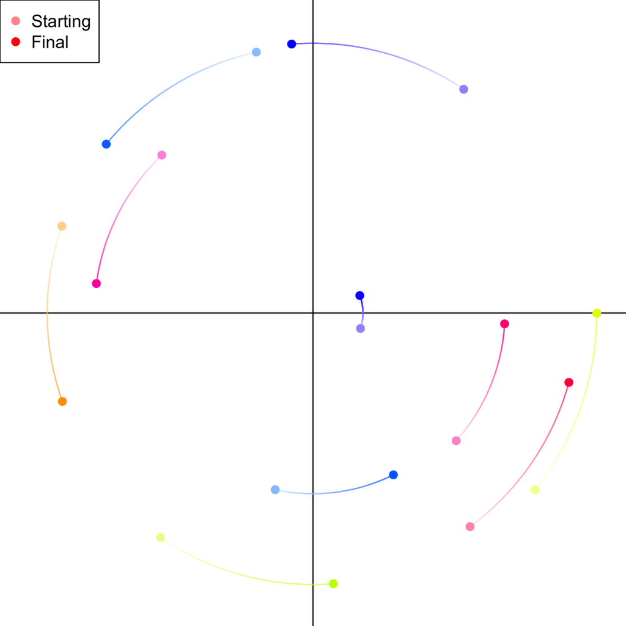

The starting points are stored as rows in a 10 $\times$ 2 matrix $S$.

$$S=\begin{bmatrix}
5.2 & 7.721\\
-8.668 & 2.996\\
4.941 & -4.408\\
5.418 & -7.371\\
1.639 & -0.534\\
7.659 & -6.102\\
-5.265 & -7.748\\
-1.955 & 9.001\\
-5.216 & 5.449\\
-1.305 & -6.097
\end{bmatrix}$$

The 2D-rotation matrix can be found by using $\theta=0.672$ in the formula below.

$$R~=~\begin{bmatrix}\cos(\theta)&\sin(\theta)\\
-\sin(\theta) & \cos(\theta)\end{bmatrix}$$

The final points (in matrix $F$) are found by multiplying $S\cdot R$.

$$F=S\cdot R$$

That multiplication can be done using the diagram below.

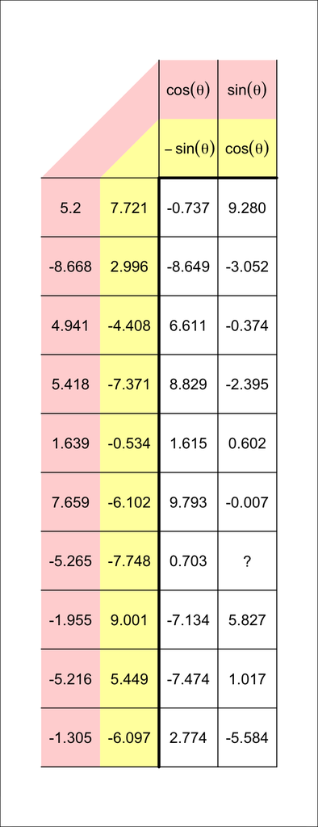

As denoted by the question mark in the diagram above, when the point $(-5.265,-7.748)$ is rotated by 0.672 radians, what is the new $y$ coordinate? The tolerance is $\pm 0.001$.

First, you can get decimal approximations for the rotation-matrix elements by using $\theta=0.672$.

$$R=\begin{bmatrix}
0.782578127091948 & 0.622552387351666\\
-0.622552387351666 & 0.782578127091948
\end{bmatrix}$$

The initial point $(-5.265,-7.748)$ is in row 7 of $S$. Because we want to find the new $y$ coordinate, use column 2 of $R$.

$$(-5.265)(0.6225524)~+~(-7.748)(0.7825781)$$

So, the new $y$ coordinate is -9.3411536.

A video-game developer is hoping to rotate a set of points around the origin by 1.039 radians counterclockwise by using matrix multiplication.

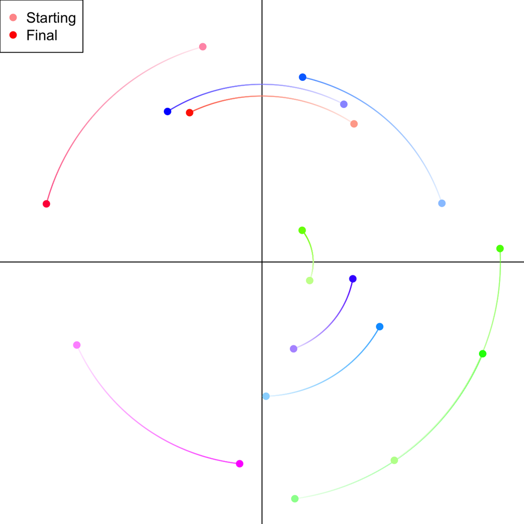

The starting points are stored as rows in a 10 $\times$ 2 matrix $S$.

$$S=\begin{bmatrix}
1.354 & -9.758\\
0.164 & -5.533\\
5.454 & -8.175\\
7.416 & 2.421\\
1.302 & -3.578\\
-7.634 & -3.422\\
3.373 & 6.502\\
3.793 & 5.694\\
-2.441 & 8.875\\
1.966 & -0.764
\end{bmatrix}$$

The 2D-rotation matrix can be found by using $\theta=1.039$ in the formula below.

$$R~=~\begin{bmatrix}\cos(\theta)&\sin(\theta)\\
-\sin(\theta) & \cos(\theta)\end{bmatrix}$$

The final points (in matrix $F$) are found by multiplying $S\cdot R$.

$$F=S\cdot R$$

That multiplication can be done using the diagram below.

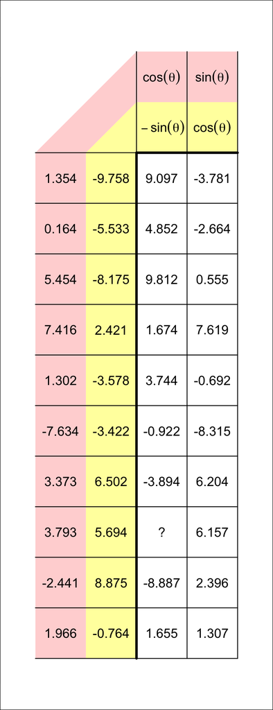

As denoted by the question mark in the diagram above, when the point $(3.793,5.694)$ is rotated by 1.039 radians, what is the new $x$ coordinate? The tolerance is $\pm 0.001$.

First, you can get decimal approximations for the rotation-matrix elements by using $\theta=1.039$.

$$R=\begin{bmatrix}
0.50708240820618 & 0.861897575868398\\
-0.861897575868398 & 0.50708240820618
\end{bmatrix}$$

The initial point $(3.793,5.694)$ is in row 8 of $S$. Because we want to find the new $x$ coordinate, use column 1 of $R$.

$$(3.793)(0.5070824)~+~(5.694)(-0.8618976)$$

So, the new $x$ coordinate is -2.9842812.

A video-game developer is hoping to rotate a set of points around the origin by 0.589 radians counterclockwise by using matrix multiplication.

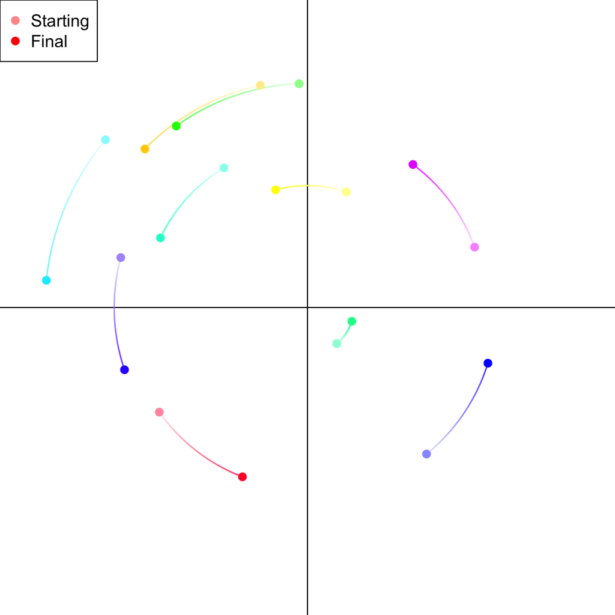

The starting points are stored as rows in a 10 $\times$ 2 matrix $S$.

$$S=\begin{bmatrix}
5.869 & 2.119\\
-1.656 & 7.803\\
-5.203 & -3.675\\
-0.293 & 7.861\\
-2.936 & 4.903\\
-7.095 & 5.89\\
-6.558 & 1.753\\
4.182 & -5.146\\
1.026 & -1.268\\
1.366 & 4.058
\end{bmatrix}$$

The 2D-rotation matrix can be found by using $\theta=0.589$ in the formula below.

$$R~=~\begin{bmatrix}\cos(\theta)&\sin(\theta)\\
-\sin(\theta) & \cos(\theta)\end{bmatrix}$$

The final points (in matrix $F$) are found by multiplying $S\cdot R$.

$$F=S\cdot R$$

That multiplication can be done using the diagram below.

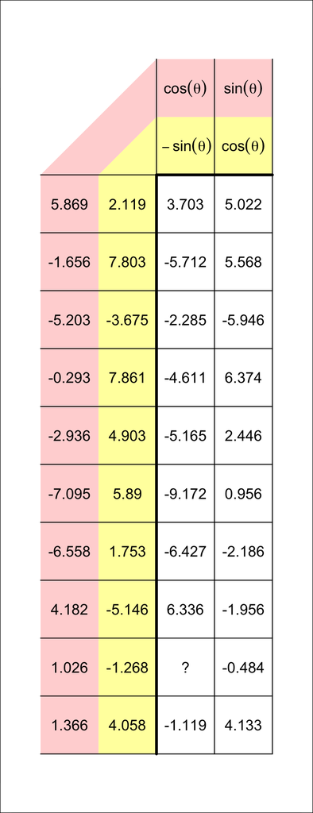

As denoted by the question mark in the diagram above, when the point $(1.026,-1.268)$ is rotated by 0.589 radians, what is the new $x$ coordinate? The tolerance is $\pm 0.001$.

First, you can get decimal approximations for the rotation-matrix elements by using $\theta=0.589$.

$$R=\begin{bmatrix}
0.831496624560044 & 0.555529804191685\\
-0.555529804191685 & 0.831496624560044
\end{bmatrix}$$

The initial point $(1.026,-1.268)$ is in row 9 of $S$. Because we want to find the new $x$ coordinate, use column 1 of $R$.

$$(1.026)(0.8314966)~+~(-1.268)(-0.5555298)$$

So, the new $x$ coordinate is 1.5575273.

A video-game developer is hoping to rotate a set of points around the origin by 0.951 radians counterclockwise by using matrix multiplication.

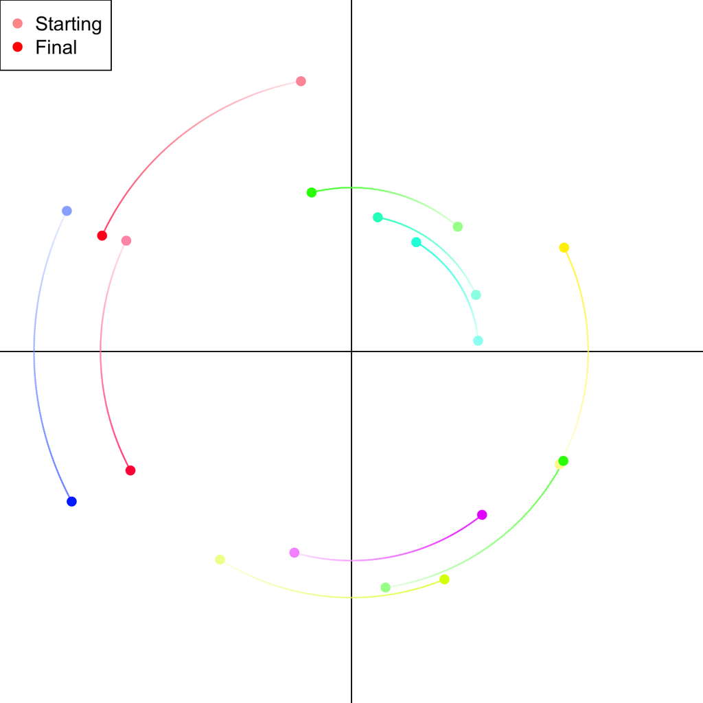

The starting points are stored as rows in a 10 $\times$ 2 matrix $S$.

$$S=\begin{bmatrix}
1.045 & -7.251\\
3.825 & 1.738\\
3.89 & 0.332\\
-6.92 & 3.405\\
-1.553 & 8.305\\
6.394 & -3.464\\
-8.746 & 4.32\\
3.265 & 3.835\\
-1.755 & -6.181\\
-4.04 & -6.392
\end{bmatrix}$$

The 2D-rotation matrix can be found by using $\theta=0.951$ in the formula below.

$$R~=~\begin{bmatrix}\cos(\theta)&\sin(\theta)\\
-\sin(\theta) & \cos(\theta)\end{bmatrix}$$

The final points (in matrix $F$) are found by multiplying $S\cdot R$.

$$F=S\cdot R$$

That multiplication can be done using the diagram below.

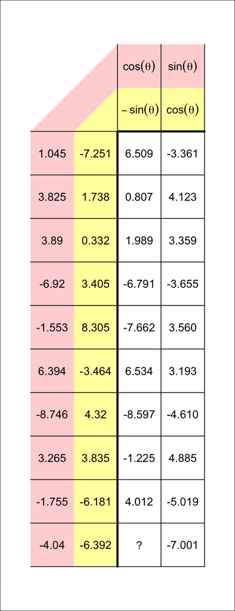

As denoted by the question mark in the diagram above, when the point $(-4.04,-6.392)$ is rotated by 0.951 radians, what is the new $x$ coordinate? The tolerance is $\pm 0.001$.

First, you can get decimal approximations for the rotation-matrix elements by using $\theta=0.951$.

$$R=\begin{bmatrix}
0.580869383253143 & 0.813996781074172\\
-0.813996781074172 & 0.580869383253143
\end{bmatrix}$$

The initial point $(-4.04,-6.392)$ is in row 10 of $S$. Because we want to find the new $x$ coordinate, use column 1 of $R$.

$$(-4.04)(0.5808694)~+~(-6.392)(-0.8139968)$$

So, the new $x$ coordinate is 2.8563551.

A video-game developer is hoping to rotate a set of points around the origin by 1 radians counterclockwise by using matrix multiplication.

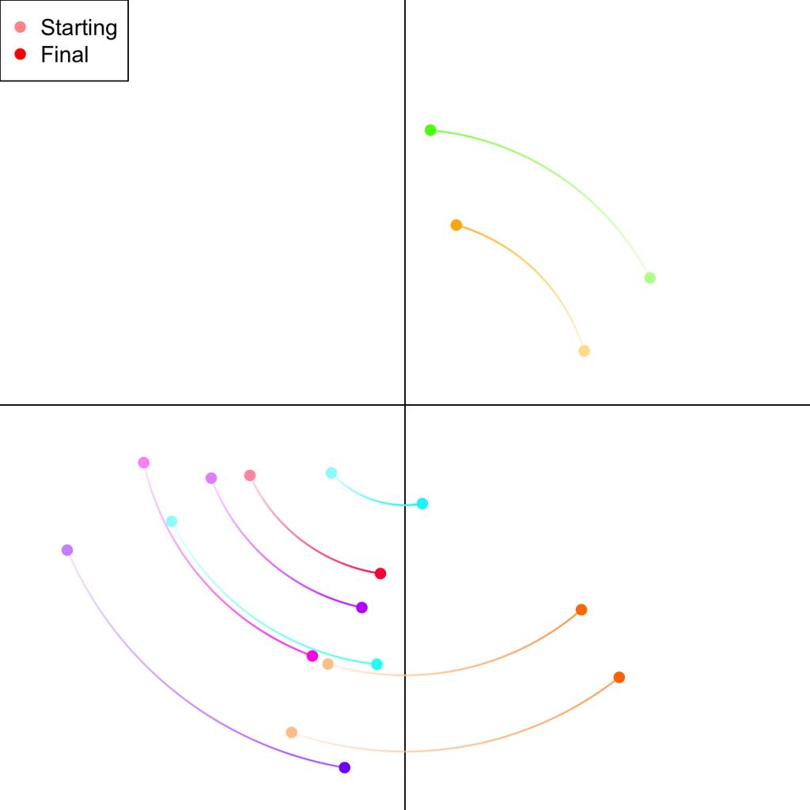

The starting points are stored as rows in a 10 $\times$ 2 matrix $S$.

$$S=\begin{bmatrix}
-9.006 & -3.87\\
-1.963 & -1.81\\
-5.167 & -1.95\\
-2.053 & -6.908\\
-3.024 & -8.731\\
-4.135 & -1.878\\
-6.966 & -1.537\\
6.534 & 3.388\\
-6.224 & -3.103\\
4.778 & 1.441
\end{bmatrix}$$

The 2D-rotation matrix can be found by using $\theta=1$ in the formula below.

$$R~=~\begin{bmatrix}\cos(\theta)&\sin(\theta)\\
-\sin(\theta) & \cos(\theta)\end{bmatrix}$$

The final points (in matrix $F$) are found by multiplying $S\cdot R$.

$$F=S\cdot R$$

That multiplication can be done using the diagram below.

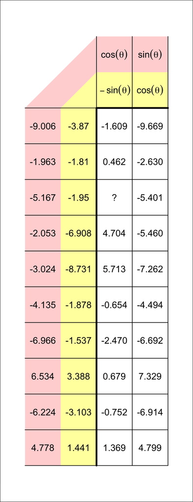

As denoted by the question mark in the diagram above, when the point $(-5.167,-1.95)$ is rotated by 1 radians, what is the new $x$ coordinate? The tolerance is $\pm 0.001$.

First, you can get decimal approximations for the rotation-matrix elements by using $\theta=1$.

$$R=\begin{bmatrix}
0.54030230586814 & 0.841470984807897\\
-0.841470984807897 & 0.54030230586814
\end{bmatrix}$$

The initial point $(-5.167,-1.95)$ is in row 3 of $S$. Because we want to find the new $x$ coordinate, use column 1 of $R$.

$$(-5.167)(0.5403023)~+~(-1.95)(-0.841471)$$

So, the new $x$ coordinate is -1.1508736.

A video-game developer is hoping to rotate a set of points around the origin by 0.9 radians counterclockwise by using matrix multiplication.

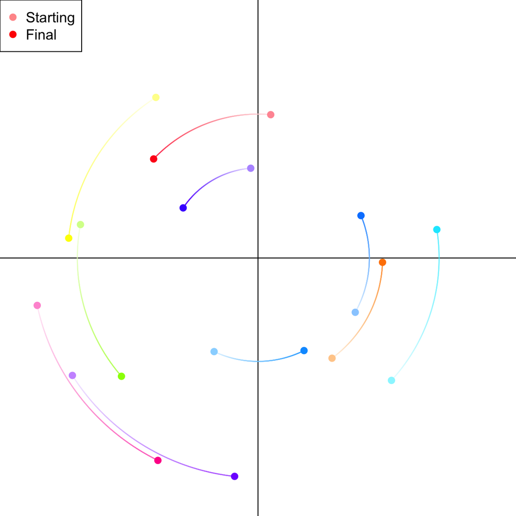

The starting points are stored as rows in a 10 $\times$ 2 matrix $S$.

$$S=\begin{bmatrix}
3.099 & -4.195\\
-9.242 & -1.984\\
5.587 & -5.124\\
-1.838 & -3.918\\
-7.432 & 1.399\\
-0.304 & 3.758\\
0.532 & 6\\
4.071 & -2.273\\
-4.275 & 6.723\\
-7.769 & -4.915
\end{bmatrix}$$

The 2D-rotation matrix can be found by using $\theta=0.9$ in the formula below.

$$R~=~\begin{bmatrix}\cos(\theta)&\sin(\theta)\\
-\sin(\theta) & \cos(\theta)\end{bmatrix}$$

The final points (in matrix $F$) are found by multiplying $S\cdot R$.

$$F=S\cdot R$$

That multiplication can be done using the diagram below.

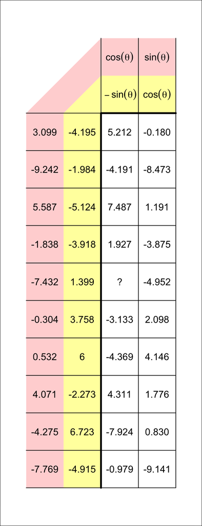

As denoted by the question mark in the diagram above, when the point $(-7.432,1.399)$ is rotated by 0.9 radians, what is the new $x$ coordinate? The tolerance is $\pm 0.001$.

First, you can get decimal approximations for the rotation-matrix elements by using $\theta=0.9$.

$$R=\begin{bmatrix}
0.621609968270664 & 0.783326909627483\\
-0.783326909627483 & 0.621609968270664
\end{bmatrix}$$

The initial point $(-7.432,1.399)$ is in row 5 of $S$. Because we want to find the new $x$ coordinate, use column 1 of $R$.

$$(-7.432)(0.62161)~+~(1.399)(-0.7833269)$$

So, the new $x$ coordinate is -5.7156796.

A video-game developer is hoping to rotate a set of points around the origin by 1.106 radians counterclockwise by using matrix multiplication.

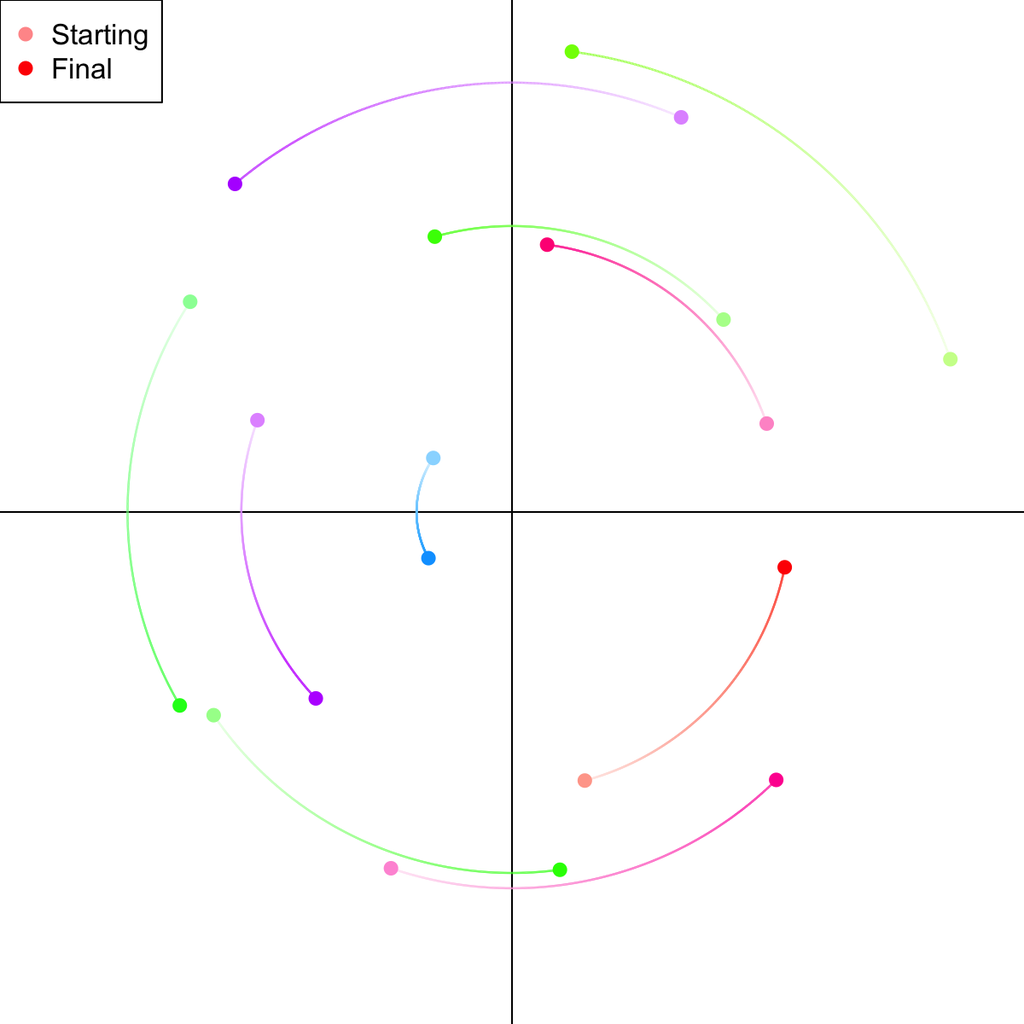

The starting points are stored as rows in a 10 $\times$ 2 matrix $S$.

$$S=\begin{bmatrix}
3.568 & 8.325\\
9.247 & 3.223\\
-1.66 & 1.139\\
1.536 & -5.665\\
-6.293 & -4.286\\
-5.37 & 1.937\\
5.373 & 1.865\\
4.462 & 4.059\\
-6.789 & 4.435\\
-2.553 & -7.515
\end{bmatrix}$$

The 2D-rotation matrix can be found by using $\theta=1.106$ in the formula below.

$$R~=~\begin{bmatrix}\cos(\theta)&\sin(\theta)\\
-\sin(\theta) & \cos(\theta)\end{bmatrix}$$

The final points (in matrix $F$) are found by multiplying $S\cdot R$.

$$F=S\cdot R$$

That multiplication can be done using the diagram below.

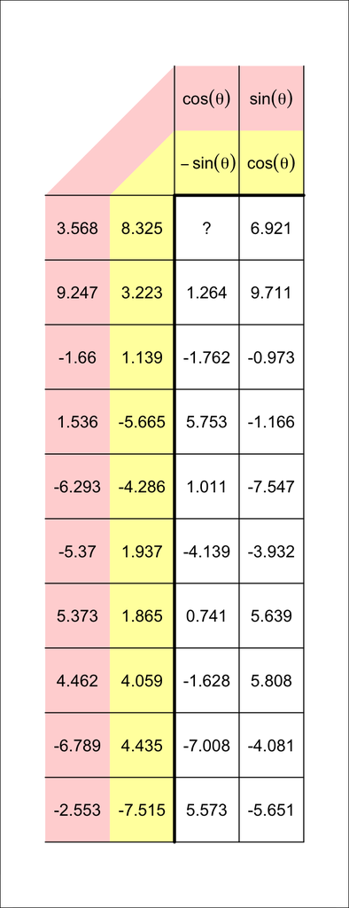

As denoted by the question mark in the diagram above, when the point $(3.568,8.325)$ is rotated by 1.106 radians, what is the new $x$ coordinate? The tolerance is $\pm 0.001$.

First, you can get decimal approximations for the rotation-matrix elements by using $\theta=1.106$.

$$R=\begin{bmatrix}
0.448240744642924 & 0.893912878776202\\
-0.893912878776202 & 0.448240744642924
\end{bmatrix}$$

The initial point $(3.568,8.325)$ is in row 1 of $S$. Because we want to find the new $x$ coordinate, use column 1 of $R$.

$$(3.568)(0.4482407)~+~(8.325)(-0.8939129)$$

So, the new $x$ coordinate is -5.8425017.

A video-game developer is hoping to rotate a set of points around the origin by 1.056 radians counterclockwise by using matrix multiplication.

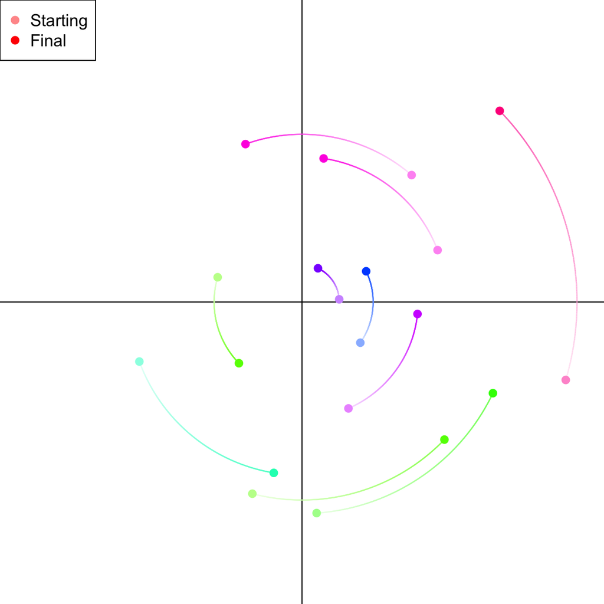

The starting points are stored as rows in a 10 $\times$ 2 matrix $S$.

$$S=\begin{bmatrix}
4.849 & 1.855\\
9.432 & -2.788\\
-3.016 & 0.885\\
3.92 & 4.539\\
-5.816 & -2.13\\
1.331 & 0.096\\
-1.775 & -6.856\\
1.661 & -3.806\\
0.523 & -7.548\\
2.086 & -1.456
\end{bmatrix}$$

The 2D-rotation matrix can be found by using $\theta=1.056$ in the formula below.

$$R~=~\begin{bmatrix}\cos(\theta)&\sin(\theta)\\
-\sin(\theta) & \cos(\theta)\end{bmatrix}$$

The final points (in matrix $F$) are found by multiplying $S\cdot R$.

$$F=S\cdot R$$

That multiplication can be done using the diagram below.

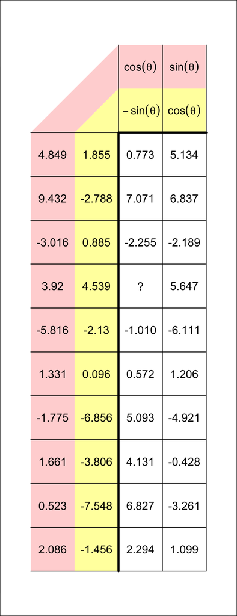

As denoted by the question mark in the diagram above, when the point $(3.92,4.539)$ is rotated by 1.056 radians, what is the new $x$ coordinate? The tolerance is $\pm 0.001$.

First, you can get decimal approximations for the rotation-matrix elements by using $\theta=1.056$.

$$R=\begin{bmatrix}
0.49235758351335 & 0.870393020397622\\
-0.870393020397622 & 0.49235758351335
\end{bmatrix}$$

The initial point $(3.92,4.539)$ is in row 4 of $S$. Because we want to find the new $x$ coordinate, use column 1 of $R$.

$$(3.92)(0.4923576)~+~(4.539)(-0.870393)$$

So, the new $x$ coordinate is -2.0206722.

A video-game developer is hoping to rotate a set of points around the origin by 0.403 radians counterclockwise by using matrix multiplication.

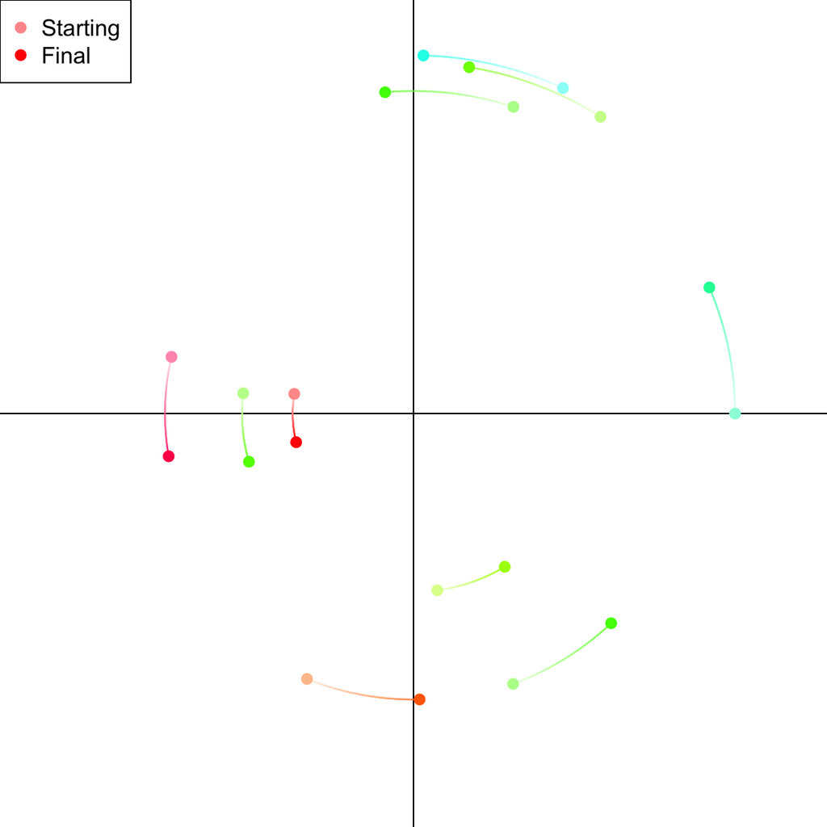

The starting points are stored as rows in a 10 $\times$ 2 matrix $S$.

$$S=\begin{bmatrix}
3.905 & 8.5\\
-3.113 & 0.512\\
-6.32 & 1.48\\
8.4 & -0.002\\
2.609 & 8.009\\
0.623 & -4.618\\
4.885 & 7.75\\
2.601 & -7.063\\
-2.782 & -6.933\\
-4.447 & 0.527
\end{bmatrix}$$

The 2D-rotation matrix can be found by using $\theta=0.403$ in the formula below.

$$R~=~\begin{bmatrix}\cos(\theta)&\sin(\theta)\\
-\sin(\theta) & \cos(\theta)\end{bmatrix}$$

The final points (in matrix $F$) are found by multiplying $S\cdot R$.

$$F=S\cdot R$$

That multiplication can be done using the diagram below.

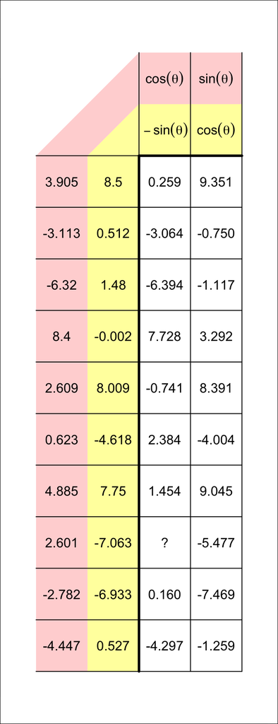

As denoted by the question mark in the diagram above, when the point $(2.601,-7.063)$ is rotated by 0.403 radians, what is the new $x$ coordinate? The tolerance is $\pm 0.001$.

First, you can get decimal approximations for the rotation-matrix elements by using $\theta=0.403$.

$$R=\begin{bmatrix}
0.919888595956976 & 0.39217976876466\\
-0.39217976876466 & 0.919888595956976
\end{bmatrix}$$

The initial point $(2.601,-7.063)$ is in row 8 of $S$. Because we want to find the new $x$ coordinate, use column 1 of $R$.

$$(2.601)(0.9198886)~+~(-7.063)(-0.3921798)$$

So, the new $x$ coordinate is 5.1625959.

A video-game developer is hoping to rotate a set of points around the origin by 1.122 radians counterclockwise by using matrix multiplication.

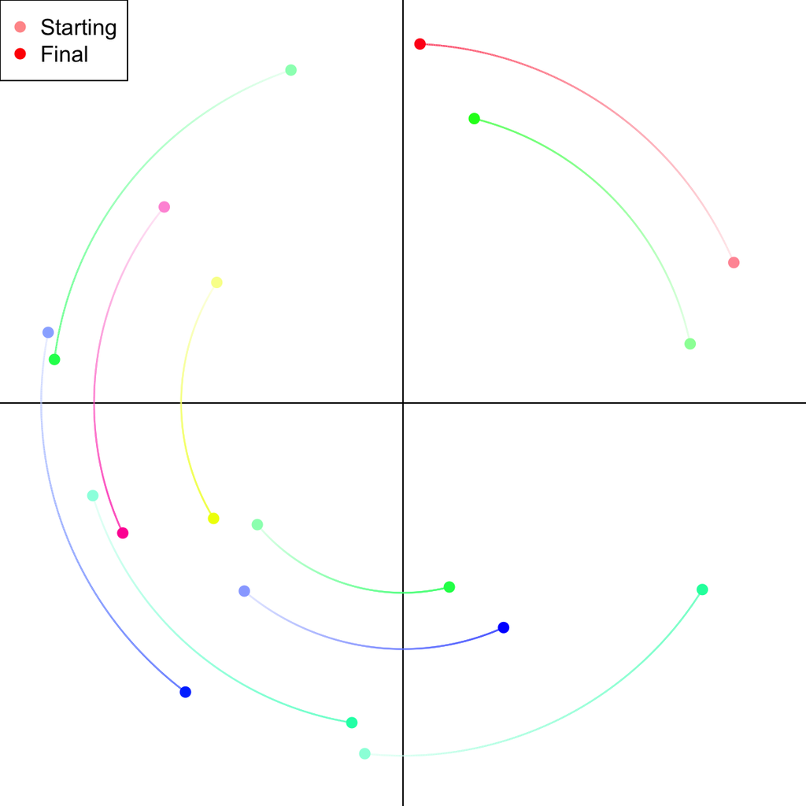

The starting points are stored as rows in a 10 $\times$ 2 matrix $S$.

$$S=\begin{bmatrix}
-4.99 & 3.231\\
-3.904 & -3.259\\
-1.024 & -9.397\\
-8.313 & -2.482\\
-9.509 & 1.892\\
7.696 & 1.586\\
8.866 & 3.764\\
-3.002 & 8.922\\
-6.398 & 5.254\\
-4.252 & -5.04
\end{bmatrix}$$

The 2D-rotation matrix can be found by using $\theta=1.122$ in the formula below.

$$R~=~\begin{bmatrix}\cos(\theta)&\sin(\theta)\\
-\sin(\theta) & \cos(\theta)\end{bmatrix}$$

The final points (in matrix $F$) are found by multiplying $S\cdot R$.

$$F=S\cdot R$$

That multiplication can be done using the diagram below.

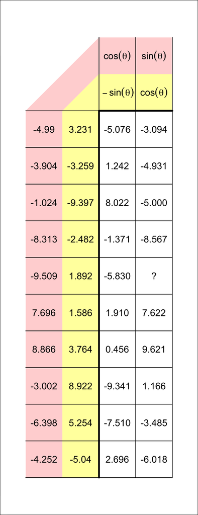

As denoted by the question mark in the diagram above, when the point $(-9.509,1.892)$ is rotated by 1.122 radians, what is the new $y$ coordinate? The tolerance is $\pm 0.001$.

First, you can get decimal approximations for the rotation-matrix elements by using $\theta=1.122$.

$$R=\begin{bmatrix}
0.433881375227891 & 0.900970006287864\\
-0.900970006287864 & 0.433881375227891
\end{bmatrix}$$

The initial point $(-9.509,1.892)$ is in row 5 of $S$. Because we want to find the new $y$ coordinate, use column 2 of $R$.

$$(-9.509)(0.90097)~+~(1.892)(0.4338814)$$

So, the new $y$ coordinate is -7.7464202.

A video-game developer is hoping to apply a horizontal [shear](https://en.wikipedia.org/wiki/Shear_mapping) to a set of points by using matrix multiplication.

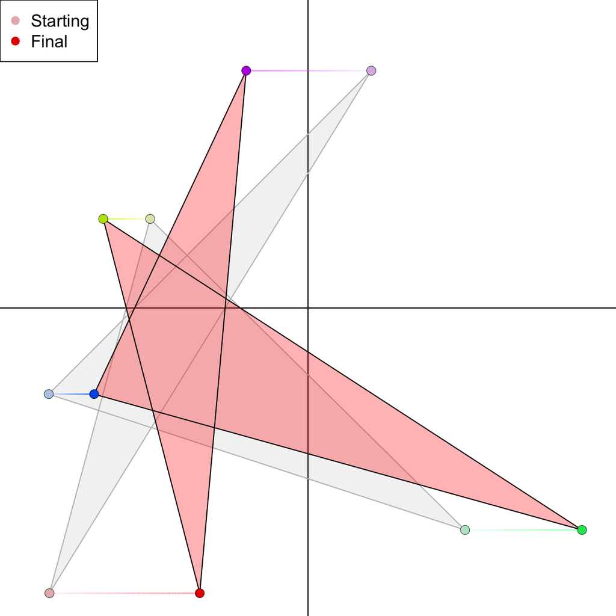

The starting points are stored as rows in a 5 $\times$ 2 matrix $S$.

$$S=\begin{bmatrix}
-5.374 & -5.928\\
-3.281 & 1.852\\
3.264 & -4.614\\
-5.389 & -1.79\\
1.316 & 4.933
\end{bmatrix}$$

The horizontal shear matrix can be found by using $k=-0.527$ in the formula matrix.

$$T~=~\begin{bmatrix}
1 & 0\\
k & 1
\end{bmatrix}$$

The final points (in matrix $F$) are found by multiplying $S\cdot T$.

$$F=S\cdot T$$

That multiplication can be done using the diagram below.

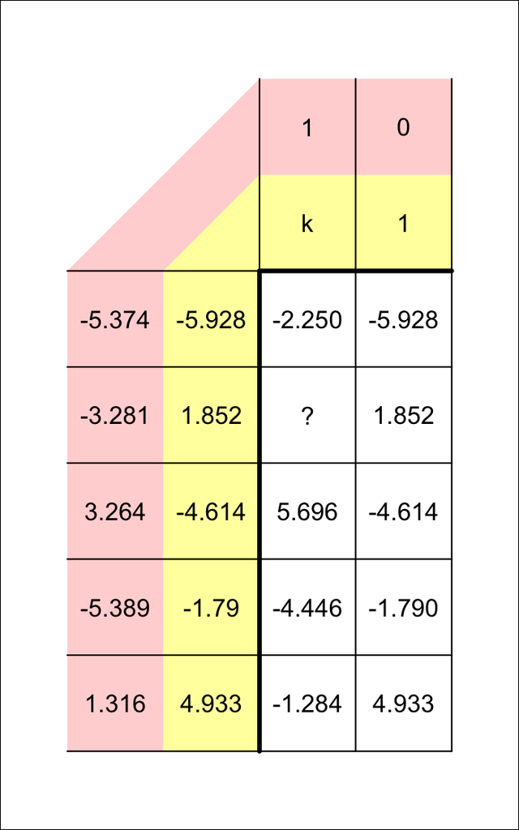

What is the new x coordinate when point $(-3.281, 1.852)$ undergoes the horizontal shear transformation with $k=-0.527$?

The horizontal shear transformation matrix:

$$T=\begin{bmatrix}
1 & 0\\
-0.527 & 1
\end{bmatrix}$$

We are looking for the new x coordinate after point $(-3.281, 1.852)$ undergoes the shear transformation. Use column 1 of $T$:

$$(-3.281)(1)~+~(1.852)(-0.527)$$

The new x coordinate is -4.257004.

A video-game developer is hoping to apply a vertical [shear](https://en.wikipedia.org/wiki/Shear_mapping) to a set of points by using matrix multiplication.

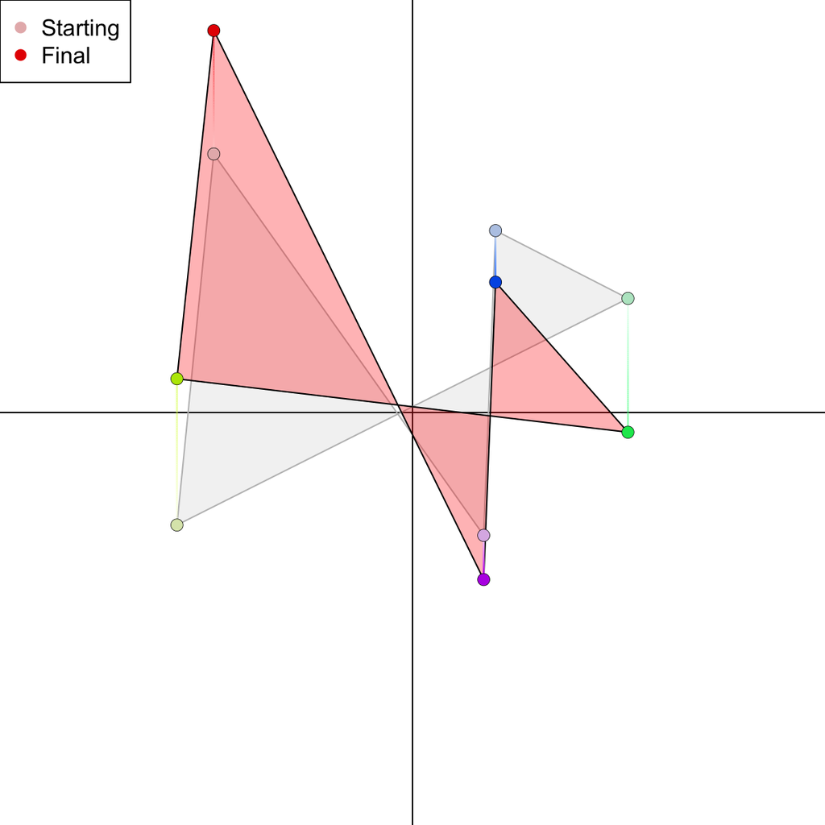

The starting points are stored as rows in a 5 $\times$ 2 matrix $S$.

$$S=\begin{bmatrix}
-4.463 & 5.806\\
-5.29 & -2.527\\
4.839 & 2.562\\
1.865 & 4.085\\
1.599 & -2.759
\end{bmatrix}$$

The vertical shear matrix can be found by using $k=-0.621$ in the formula matrix.

$$T~=~\begin{bmatrix}
1 & k\\
0 & 1
\end{bmatrix}$$

The final points (in matrix $F$) are found by multiplying $S\cdot T$.

$$F=S\cdot T$$

That multiplication can be done using the diagram below.

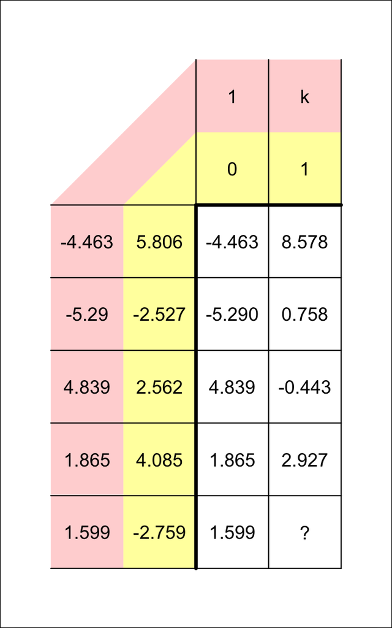

What is the new y coordinate when point $(1.599, -2.759)$ undergoes the vertical shear transformation with $k=-0.621$?

The vertical shear transformation matrix:

$$T=\begin{bmatrix}
1 & -0.621\\
0 & 1
\end{bmatrix}$$

We are looking for the new y coordinate after point $(1.599, -2.759)$ undergoes the shear transformation. Use column 2 of $T$:

$$(1.599)(-0.621)~+~(-2.759)(1)$$

The new y coordinate is -3.751979.

A video-game developer is hoping to apply a vertical [shear](https://en.wikipedia.org/wiki/Shear_mapping) to a set of points by using matrix multiplication.

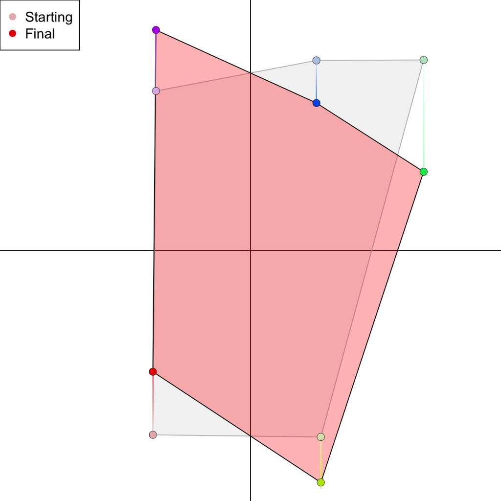

The starting points are stored as rows in a 5 $\times$ 2 matrix $S$.

$$S=\begin{bmatrix}
-2.814 & -5.311\\
2.027 & -5.374\\
4.989 & 5.491\\
1.899 & 5.477\\
-2.724 & 4.595
\end{bmatrix}$$

The vertical shear matrix can be found by using $k=-0.646$ in the formula matrix.

$$T~=~\begin{bmatrix}
1 & k\\
0 & 1
\end{bmatrix}$$

The final points (in matrix $F$) are found by multiplying $S\cdot T$.

$$F=S\cdot T$$

That multiplication can be done using the diagram below.

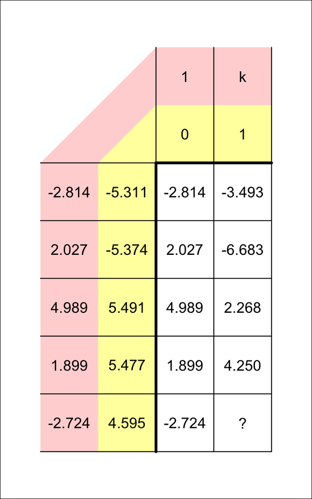

What is the new y coordinate when point $(-2.724, 4.595)$ undergoes the vertical shear transformation with $k=-0.646$?

The vertical shear transformation matrix:

$$T=\begin{bmatrix}
1 & -0.646\\
0 & 1
\end{bmatrix}$$

We are looking for the new y coordinate after point $(-2.724, 4.595)$ undergoes the shear transformation. Use column 2 of $T$:

$$(-2.724)(-0.646)~+~(4.595)(1)$$

The new y coordinate is 6.354704.

A video-game developer is hoping to apply a horizontal [shear](https://en.wikipedia.org/wiki/Shear_mapping) to a set of points by using matrix multiplication.

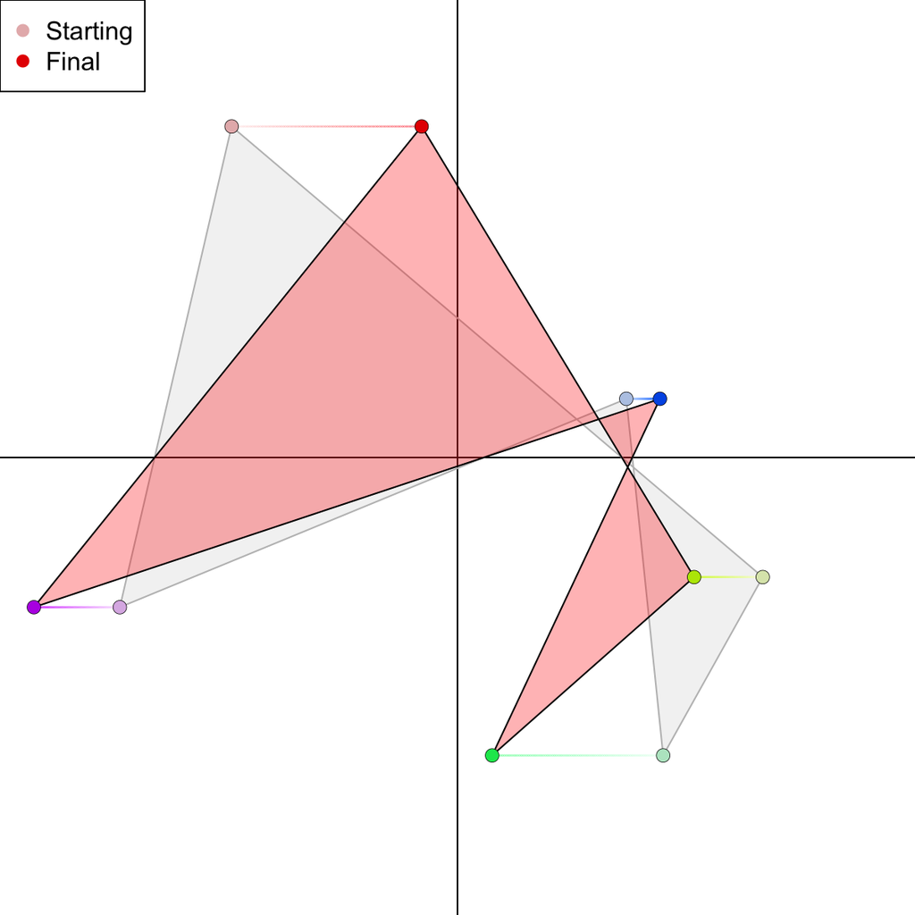

The starting points are stored as rows in a 5 $\times$ 2 matrix $S$.

$$S=\begin{bmatrix}
-4.002 & 5.866\\
5.409 & -2.119\\
3.644 & -5.279\\
2.991 & 1.04\\
-5.983 & -2.653
\end{bmatrix}$$

The horizontal shear matrix can be found by using $k=0.574$ in the formula matrix.

$$T~=~\begin{bmatrix}
1 & 0\\
k & 1
\end{bmatrix}$$

The final points (in matrix $F$) are found by multiplying $S\cdot T$.

$$F=S\cdot T$$

That multiplication can be done using the diagram below.

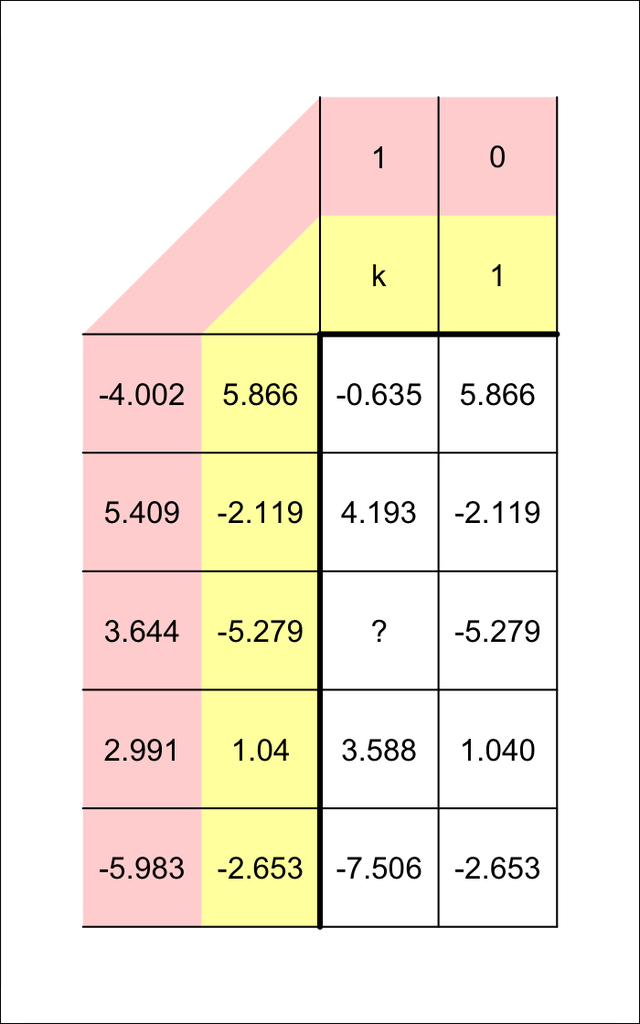

What is the new x coordinate when point $(3.644, -5.279)$ undergoes the horizontal shear transformation with $k=0.574$?

The horizontal shear transformation matrix:

$$T=\begin{bmatrix}
1 & 0\\
0.574 & 1
\end{bmatrix}$$

We are looking for the new x coordinate after point $(3.644, -5.279)$ undergoes the shear transformation. Use column 1 of $T$:

$$(3.644)(1)~+~(-5.279)(0.574)$$

The new x coordinate is 0.613854.

A video-game developer is hoping to apply a vertical [shear](https://en.wikipedia.org/wiki/Shear_mapping) to a set of points by using matrix multiplication.

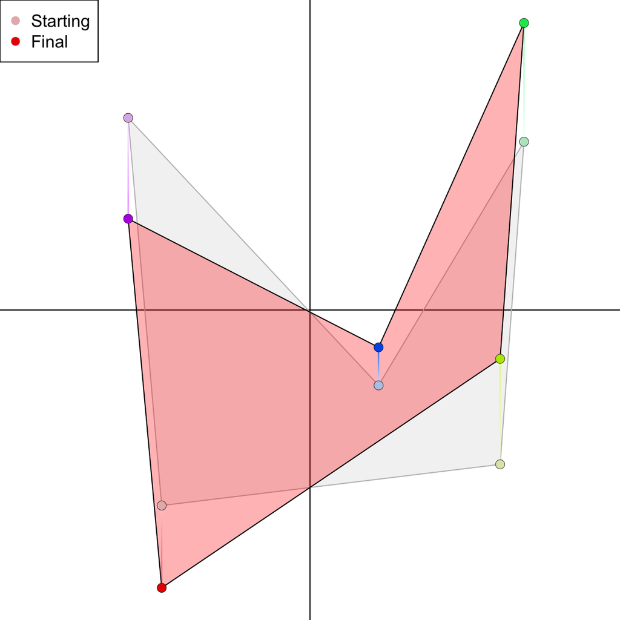

The starting points are stored as rows in a 5 $\times$ 2 matrix $S$.

$$S=\begin{bmatrix}
-3.985 & -5.254\\
5.109 & -4.147\\
5.751 & 4.521\\
1.843 & -2.026\\
-4.886 & 5.163
\end{bmatrix}$$

The vertical shear matrix can be found by using $k=0.555$ in the formula matrix.

$$T~=~\begin{bmatrix}
1 & k\\
0 & 1
\end{bmatrix}$$

The final points (in matrix $F$) are found by multiplying $S\cdot T$.

$$F=S\cdot T$$

That multiplication can be done using the diagram below.

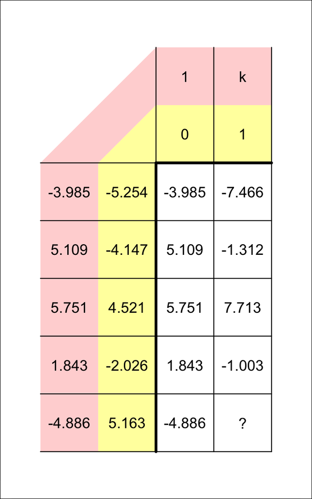

What is the new y coordinate when point $(-4.886, 5.163)$ undergoes the vertical shear transformation with $k=0.555$?

The vertical shear transformation matrix:

$$T=\begin{bmatrix}
1 & 0.555\\
0 & 1
\end{bmatrix}$$

We are looking for the new y coordinate after point $(-4.886, 5.163)$ undergoes the shear transformation. Use column 2 of $T$:

$$(-4.886)(0.555)~+~(5.163)(1)$$

The new y coordinate is 2.45127.

A video-game developer is hoping to apply a vertical [shear](https://en.wikipedia.org/wiki/Shear_mapping) to a set of points by using matrix multiplication.

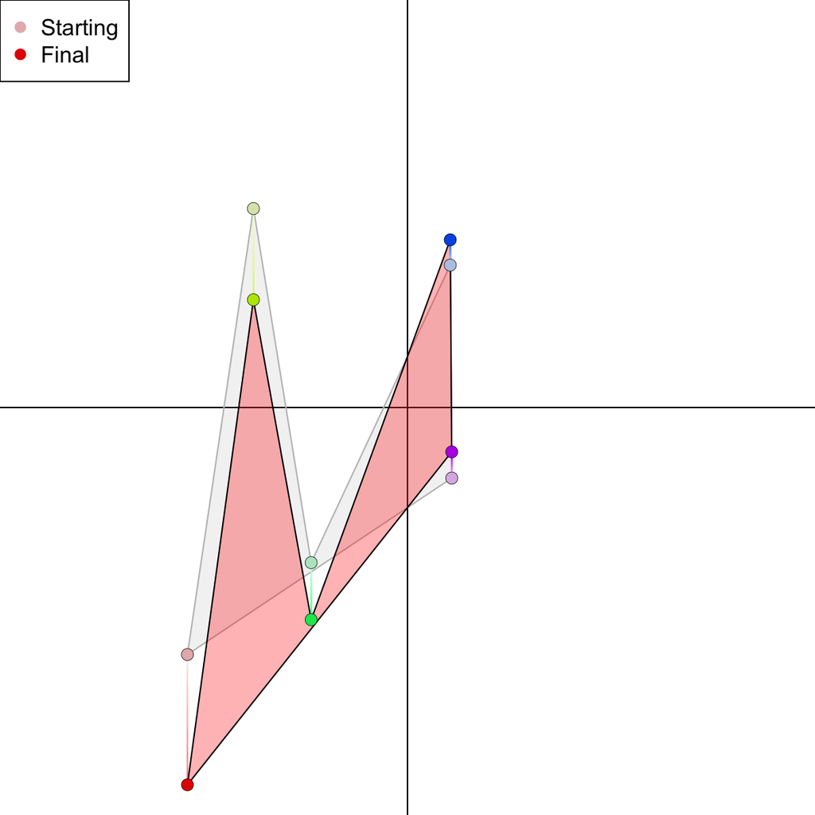

The starting points are stored as rows in a 5 $\times$ 2 matrix $S$.

$$S=\begin{bmatrix}
-5.298 & -5.947\\
-3.709 & 4.789\\
-2.319 & -3.735\\
1.029 & 3.428\\
1.065 & -1.699
\end{bmatrix}$$

The vertical shear matrix can be found by using $k=0.592$ in the formula matrix.

$$T~=~\begin{bmatrix}
1 & k\\
0 & 1
\end{bmatrix}$$

The final points (in matrix $F$) are found by multiplying $S\cdot T$.

$$F=S\cdot T$$

That multiplication can be done using the diagram below.

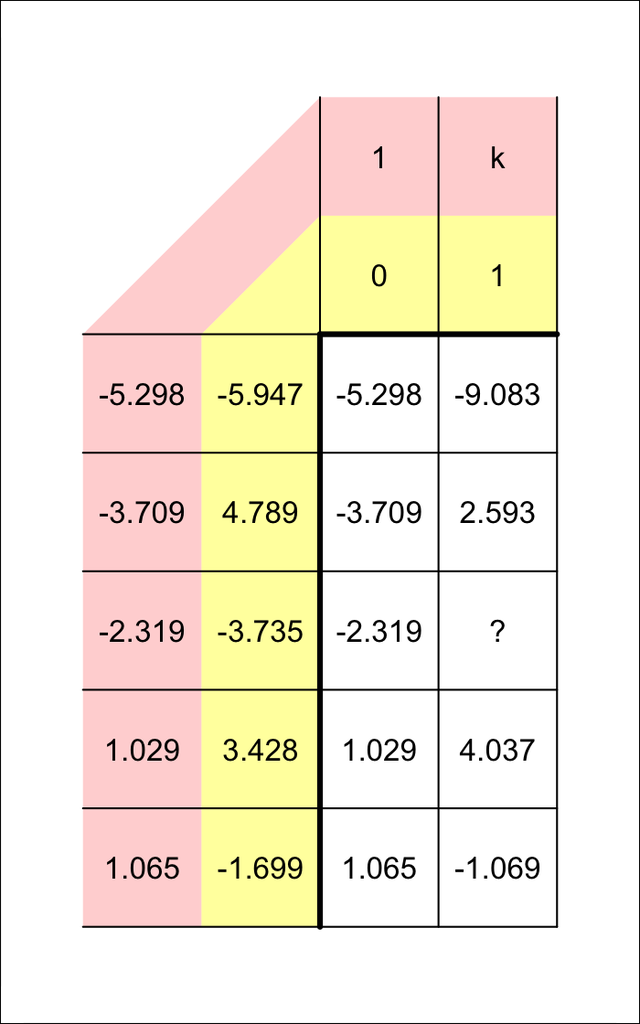

What is the new y coordinate when point $(-2.319, -3.735)$ undergoes the vertical shear transformation with $k=0.592$?

The vertical shear transformation matrix:

$$T=\begin{bmatrix}
1 & 0.592\\
0 & 1
\end{bmatrix}$$

We are looking for the new y coordinate after point $(-2.319, -3.735)$ undergoes the shear transformation. Use column 2 of $T$:

$$(-2.319)(0.592)~+~(-3.735)(1)$$

The new y coordinate is -5.107848.